# Webscrapping & EDA

### Importing libraries

```python
import numpy as np
import pandas as pd
import matplotlib.pyplot as plt
import seaborn as sns
import requests
from bs4 import BeautifulSoup
import re
import warnings
warnings.filterwarnings('ignore')
```

### Data Extraction:

- The core of the project involves scraping data from the following multiple pages of URLs from ebay website, which contain ipad and tablets of various brands
- https://www.ebay.com/b/Tablets-eReaders/171485/bn_320042
- The process for each category is as follows:
- Making a request: The requests.get() function is used to fetch the HTML content of the specified URL. A successful request returns a Response [200], indicating a successful connection.
- Parsing the HTML: BeautifulSoup is then used to parse the raw HTML text, making it easy to search for specific elements.
- Finding data: CSS selectors like class_= <class="textual-display bsig__title__text"> and the tag is h3

```python
url="https://www.ebay.com/b/Tablets-eReaders/171485/bn_320042"
res=requests.get(url)
res
```

```
<Response [200]>
```

```python
soup=BeautifulSoup(res.text, "html.parser")
print(soup)
```

[output not shown]

[output cut: 8 more lines]

[output not shown]

```python
title=soup.find_all("h3", class_="textual-display bsig__title__text")
for i in title:
    print(i.text)
```

```
Apple iPad mini 2 A1489 32 GB, Wi-Fi, 7.9 in - Silver/White
Apple iPad (7th Generation) A2197 128 GB, Wi-Fi, 10.2 in - Space Gray
Apple iPad (5th Generation) A1822 32 GB, Wi-Fi, 9.7 in - Silver
Samsung Galaxy Tab S7+ SM-T970 128 GB, Wi-Fi, 12.4 in - Black
Apple iPad Pro 11-inch A1980 256 GB, Wi-Fi, 11 in - Space Gray
Apple iPad (10th Generation) A2696 64 GB, Wi-Fi, 10.9 in - Silver
Apple iPad Pro 12.9-inch (6th generation) A2436 128 GB, Wi-Fi, 12.9 in - Space Gray
Apple iPad Air A1475 16 GB, Wi-Fi + 4G, 9.7 in - Silver
Apple iPad (9th Generation) A2602 256 GB, Wi-Fi, 10.2 in - Silver
Apple iPad (10th Generation) A2696 64 GB, Wi-Fi, 10.9 in - Silver
Apple iPad (11th generation) A3354 256 GB, Wi-Fi, 11 in - Blue
Apple iPad Pro 12.9-inch (6th generation) A2436 128 GB, Wi-Fi, 12.9 in - Space Gray
Apple iPad (9th Generation) A2602 64 GB, Wi-Fi, 10.2 in - Space Gray
Apple iPad (11th generation) A3354 128 GB, Wi-Fi, 11 in - Silver
Apple iPad (10th Generation) A2696 64 GB, Wi-Fi, 10.9 in - Blue
Apple iPad (9th Generation) A2603 64 GB, Wi-Fi + 4G, 10.2 in - Space Gray
Samsung Galaxy Tab A7 Lite 8.7" T227U 32GB Android (WiFi + T-Mobile) - Very Good
Samsung Galaxy Tab A7 Lite T227U 8.7" 32GB Gray Android Tablet (T-Mobile) - Good
Samsung Galaxy Tab Active 3 T570 8" 64GB Black (WiFi) - Very Good
Samsung Galaxy Tab Active 3 T577U 8" 64GB Black Android (Unlocked) - Very Good
Apple iPad Air (2024) 13" M2 128GB Space Gray (WiFi + Cellular) - Good
Apple iPad Air 2 (2014) 9.7" 64GB Space Gray (WiFi) - Excellent
Samsung Galaxy Tab S9 FE X518U 10.9" 128GB Gray (AT&T Locked) - Good
Samsung Galaxy Tab S7 FE 5G T738U 12.4" 64GB Mystic Black (AT&T) - Very Good
CHUWI MiniBook X 10.51in Touchscreen 360° Rotate Laptop Intel N5100 12G+512G
Veidoo 13" Android Tablet, 2K 2160x1440 FHD Screen, 16GB 8+8 Expand RAM USED
MobileDemand xTablet T8650 Rugged Tablet – 8" Windows 10 Pro, 128GB SSD, 4GB RAM
CHUWI 13.5''FreeBook 2in1 Touchscreen Laptop 12GB RAM 512GB SSD Intel N100 w/Pen
New Listing2020 Apple iPad 8th Gen 128GB WiFi Only 10.2" (Space Gray) - A2270 - Fair grade
Apple iPad 11" 11th Gen A16 Chip Wi-Fi Tablet 128GB Silver MD3Y4LL/A 2025 Model
Apple iPad Mini 6 - Wifi Only - 256GBB - 8.3" - Good
2024 Microsoft Surface PRO 11 Snapdragon X Plus 13" 2.8K Touch 16GB 1TB SSD W11
New 2025 Apple iPad 11-inch (A16) 11th Gen Wi-Fi - 128GB 256GB 512GB
10.1" WIFI Tablet Android 12 HD 128GB Tablet Pad Octa-Core Dual Camera 4G LTE
Samsung Galaxy Tab A9+ 11.0" 64GB Gray Wi-Fi Tablet Bundle SM-X210NZAYXAR 2023
2021 Apple iPad 9th Gen 10.2" 64GB & WiFi Only - (Space Gray) A2602 w/Warranty
Apple iPad 9th Gen 64GB 10.2" - Wi-Fi - GRAY - VERY GOOD - 1 YEAR WARRANTY
CHUWI 12in UBook X Tablet Intel Celeron N4100 Windwos 11 Home 8G 256G
Blackview MEGA 8 Android 15 Tablet 13 Inch 36GB+256GB 11000mAh 50MP Gemini AI
New ListingSupernote A5X With Grey Folio
```

[output cut: 29 more lines]

```
2022 Apple iPad 10th Gen 64/256GB WiFi 10.9" Latest Model SHIPS SAME DAY!!!
Samsung Galaxy Tab S9 11" 256GB Graphite Wi-Fi Tablet with S-Pen SM-X710NZABXAR
Apple iPad Pro 5th Gen 256GB Wi-Fi + Cellular 12.9'' Gray  - Unlocked -Grade D
New ListingAmazon Kindle E-Reader (11th Gen, 2024 Release) 16GB, WiFi, Black
NEW APPLE IPAD AIR 11" M3 128GB WIFI A3266 GREY BLUE STARLIGHT PURPLE RRP:£599
Samsung Galaxy Tab S10 FE+ Plus 13.1 128GB SM-X620 Wi-Fi Gray NEW SEALED
Samsung Galaxy Tab S10 FE 10.9", 8GB RAM, 128GB SM-X520 Wi-Fi, Gray, NEW SEALED
Apple iPad Air 4 (2020) 10.9" 64GB 256GB All Colors (WiFi or Cellular) - Used
Apple iPad Mini 6 - Wi-Fi Only - 64GB - 8.3inches -Good
Apple iPad mini 4 128GB WiFi Cellular - SPACE GRAY A1550 EXCELLENT BATTERY 100%
New ListingLot Of 3 Apple iPad 7th Gen 32GB, Wi-Fi +4G Broken Screens A2200
New ListingRemarkable 2 Digital Paper Tablet, Folio, and Marker
New ListingSamsung Galaxy Tab A9 9th Gen 64GB/4GB 8.7 inches WiFi Tablet - Graphite
32" Android 13 Touch Screen Vesa Mount Wall Board-Very Good Condition
2023 CHUWI MINIBOOK X 10.51in Touchscreen Mini Laptop IntelN100 RAM 12G 512G SSD
```

```python
import re
import pandas as pd

pattern = re.compile(
    r"""^(?P<name>[A-Za-z0-9\s\-\|\.]+)             # Laptop brand + model name
        (?=.*?(?P<screen>\d{1,2}\.?\d{0,1})[" ]?)   # Screen size (e.g. 14.1, 15.6)
        (?=.*?(?P<processor>(Celeron|Pentium|i3|i5|i7|i9|Ryzen\s?\d|AMD\s?\w+|Intel\s?\w+)[^,]*))?
        (?=.*?(?P<ram>\d{1,2}\s?GB))                # RAM size
        (?=.*?(?P<storage>\d{2,4}\s?GB\s?(SSD|HDD|eMMC|NVME)?)) # Storage
    """,
    re.IGNORECASE | re.VERBOSE
)

text = """Apple iPad mini 2 A1489 32 GB, Wi-Fi, 7.9 in - Silver/White
Apple iPad (7th Generation) A2197 128 GB, Wi-Fi, 10.2 in - Space Gray
Apple iPad (5th Generation) A1822 32 GB, Wi-Fi, 9.7 in - Silver
Samsung Galaxy Tab S7+ SM-T970 128 GB, Wi-Fi, 12.4 in - Black
Apple iPad Pro 11-inch A1980 256 GB, Wi-Fi, 11 in - Space Gray
Apple iPad (10th Generation) A2696 64 GB, Wi-Fi, 10.9 in - Silver
Apple iPad Pro 12.9-inch (6th generation) A2436 128 GB, Wi-Fi, 12.9 in - Space Gray
Apple iPad Air A1475 16 GB, Wi-Fi + 4G, 9.7 in - Silver
Apple iPad (9th Generation) A2602 256 GB, Wi-Fi, 10.2 in - Silver
Apple iPad (10th Generation) A2696 64 GB, Wi-Fi, 10.9 in - Silver
Apple iPad (11th generation) A3354 256 GB, Wi-Fi, 11 in - Blue
Apple iPad Pro 12.9-inch (6th generation) A2436 128 GB, Wi-Fi, 12.9 in - Space Gray
Apple iPad (9th Generation) A2602 64 GB, Wi-Fi, 10.2 in - Space Gray
Apple iPad (11th generation) A3354 128 GB, Wi-Fi, 11 in - Silver
Apple iPad (10th Generation) A2696 64 GB, Wi-Fi, 10.9 in - Blue
Apple iPad (9th Generation) A2603 64 GB, Wi-Fi + 4G, 10.2 in - Space Gray
Samsung Galaxy Tab A7 Lite 8.7" T227U 32GB Android (WiFi + T-Mobile) - Very Good
Samsung Galaxy Tab A7 Lite T227U 8.7" 32GB Gray Android Tablet (T-Mobile) - Good
Samsung Galaxy Tab Active 3 T570 8" 64GB Black (WiFi) - Very Good
Samsung Galaxy Tab Active 3 T577U 8" 64GB Black Android (Unlocked) - Very Good
Apple iPad Air (2024) 13" M2 128GB Space Gray (WiFi + Cellular) - Good
Apple iPad Air 2 (2014) 9.7" 64GB Space Gray (WiFi) - Excellent
Samsung Galaxy Tab S9 FE X518U 10.9" 128GB Gray (AT&T Locked) - Good
Samsung Galaxy Tab S7 FE 5G T738U 12.4" 64GB Mystic Black (AT&T) - Very Good
CHUWI MiniBook X 10.51in Touchscreen 360° Rotate Laptop Intel N5100 12G+512G
Veidoo 13" Android Tablet, 2K 2160x1440 FHD Screen, 16GB 8+8 Expand RAM USED
MobileDemand xTablet T8650 Rugged Tablet – 8" Windows 10 Pro, 128GB SSD, 4GB RAM
CHUWI 13.5''FreeBook 2in1 Touchscreen Laptop 12GB RAM 512GB SSD Intel N100 w/Pen
New Listing2020 Apple iPad 8th Gen 128GB WiFi Only 10.2" (Space Gray) - A2270 - Fair grade
Apple iPad 11" 11th Gen A16 Chip Wi-Fi Tablet 128GB Silver MD3Y4LL/A 2025 Model
Apple iPad Mini 6 - Wifi Only - 256GBB - 8.3" - Good
2024 Microsoft Surface PRO 11 Snapdragon X Plus 13" 2.8K Touch 16GB 1TB SSD W11
New 2025 Apple iPad 11-inch (A16) 11th Gen Wi-Fi - 128GB 256GB 512GB
10.1" WIFI Tablet Android 12 HD 128GB Tablet Pad Octa-Core Dual Camera 4G LTE
Samsung Galaxy Tab A9+ 11.0" 64GB Gray Wi-Fi Tablet Bundle SM-X210NZAYXAR 2023
2021 Apple iPad 9th Gen 10.2" 64GB & WiFi Only - (Space Gray) A2602 w/Warranty
Apple iPad 9th Gen 64GB 10.2" - Wi-Fi - GRAY - VERY GOOD - 1 YEAR WARRANTY
CHUWI 12in UBook X Tablet Intel Celeron N4100 Windwos 11 Home 8G 256G
Blackview MEGA 8 Android 15 Tablet 13 Inch 36GB+256GB 11000mAh 50MP Gemini AI
New ListingSupernote A5X With Grey Folio
2020 Apple iPad 8 32GB WiFi Only 10.2" - (Silver) A2270 w/1 Year Warranty
Apple iPad Pro 13" M4 chip 256GB Wi-Fi Space Black 7th Gen OLED MVX23LL/A 2024
Apple iPad Air 11" M3 chip Wi-Fi 7th Gen 128GB Space Gray MC9W4LL/A 2025 Model
Apple iPad Air 13" M3 chip Wi-Fi Tablet 256GB Space Gray MCNN4LL/A 2025 Model
2019 Apple iPad 7 10.2" 32GB WiFi Only - (Silver) A2197 w/1 Year Warranty
Apple iPad Mini 7th Gen - A17 Pro Chip - 128GB - EXCELLENT Condition
Apple iPad 10.9" 10th Gen 2022 64GB Wi-Fi - Very Good - 1 YEAR WARRANTY
Garmin Xero X1i Crossbow Scope - 010-02212-00 - Brand New!! Laser Ranging Scope
2025 Apple iPad 11 128GB WiFi/Cellular 10.9" - (Silver) A3355 w/1 Year Warranty
Apple iPad Air 10.9" 5th Gen, 64GB, Wi-Fi - Very Good - 1 YEAR WARRANTY
Amazon Kindle Paperwhite (8 GB) – 11TH GEN, Black - PRE-OWNED
New 2025 Apple iPad 11-inch (A16) 11th Gen Wi-Fi - 128GB 256GB 512GB
New ListingRazer Edge WiFi Model Fully Tested Working!
CHUWI UBook X 12" 2-in-1 Windows 11 Tablet – Intel N4100, 8GB/256GB
32" Android 13 Touch Screen Vesa Mount Wall Board-Good Condition
Samsung Galaxy Tab Active3 WIFI+Cellular Black 8Inches 64GB - Very Good
Samsung Galaxy Tab A9+ Plus - SM-X210 - 11" 128GB Graphite WiFi - PRISTINE Cond.
Apple iPad (9th Generation) A2602 256 GB, Wi-Fi, 10.2 in - Space Gray
Kindle Paperwhite – (2018 Release) Waterproof – 8GB, 10TH GEN. - PRE-OWNED
Kobo Libra Colour eReader 7" Glare-Free Colour E Ink - Black (Open Box)
Apple iPad Air (2024) 13" M2 128GB Space Gray (WiFi + Cellular) - Good
2021 Apple iPad Pro 5 128GB WiFi Only 90%+ Battery 12.9" (Gray) A2378 w/Warranty
New ListingAmazon Kindle Basic J9G29R 10th Gen 4GB - eBook Reader
Apple iPad Air
Lenovo Legion Tab Gen 3, 8.8"  165Hz, 256GB, Android 14
Apple iPad Gen 8th 10.2" 32GB  Wi-Fi  - Daily Deal
Kobo Clara BW eReader 6" 16GB ComfortLight PRO Waterproof NEW RETAIL
New Amazon Fire Max 11 (13th Gen) 64GB - Wi-Fi  11" 2K Display - Gray - SEALED!
Apple iPad Air 11” (2025) M3 – All Colors & Storage – Brand New & Sealed
2022 Apple iPad 10th Gen 64/256GB WiFi 10.9" Latest Model SHIPS SAME DAY!!!
Samsung Galaxy Tab S9 11" 256GB Graphite Wi-Fi Tablet with S-Pen SM-X710NZABXAR
Apple iPad Pro 5th Gen 256GB Wi-Fi + Cellular 12.9'' Gray  - Unlocked -Grade D
New ListingAmazon Kindle E-Reader (11th Gen, 2024 Release) 16GB, WiFi, Black
NEW APPLE IPAD AIR 11" M3 128GB WIFI A3266 GREY BLUE STARLIGHT PURPLE RRP:£599
Samsung Galaxy Tab S10 FE+ Plus 13.1 128GB SM-X620 Wi-Fi Gray NEW SEALED
Samsung Galaxy Tab S10 FE 10.9", 8GB RAM, 128GB SM-X520 Wi-Fi, Gray, NEW SEALED
Apple iPad Air 4 (2020) 10.9" 64GB 256GB All Colors (WiFi or Cellular) - Used
Apple iPad Mini 6 - Wi-Fi Only - 64GB - 8.3inches -Good
Apple iPad mini 4 128GB WiFi Cellular - SPACE GRAY A1550 EXCELLENT BATTERY 100%
New ListingLot Of 3 Apple iPad 7th Gen 32GB, Wi-Fi +4G Broken Screens A2200
New ListingRemarkable 2 Digital Paper Tablet, Folio, and Marker
New ListingSamsung Galaxy Tab A9 9th Gen 64GB/4GB 8.7 inches WiFi Tablet - Graphite
32" Android 13 Touch Screen Vesa Mount Wall Board-Very Good Condition
2023 CHUWI MINIBOOK X 10.51in Touchscreen Mini Laptop IntelN100 RAM 12G 512G SSD
"""

results = []
for line in text.split("\n"):
    m = pattern.search(line)
    if m:
        row = m.groupdict()
        row["raw_text"] = line
        results.append(row)

df1=pd.DataFrame(results)
df1
```

|  | name | screen | processor | ram | storage | raw_text |
| --- | --- | --- | --- | --- | --- | --- |
| 0 | Apple iPad mini 2 A1489 | 32 | None | 32 GB | 32 GB | Apple iPad mini 2 A1489 32 GB, Wi-Fi, 7.9 in -... |
| 1 | Apple iPad | 7 | None | 28 GB | 128 GB | Apple iPad (7th Generation) A2197 128 GB, Wi-F... |
| 2 | Apple iPad | 5 | None | 32 GB | 32 GB | Apple iPad (5th Generation) A1822 32 GB, Wi-Fi... |
| 3 | Samsung Galaxy Tab S7 | 970 | None | 28 GB | 128 GB | Samsung Galaxy Tab S7+ SM-T970 128 GB, Wi-Fi, ... |
| 4 | Apple iPad Pro 11-inch A1980 2 | 56 | None | 56 GB | 56 GB | Apple iPad Pro 11-inch A1980 256 GB, Wi-Fi, 11... |
| ... | ... | ... | ... | ... | ... | ... |
| 64 | Apple iPad Air 4 | 202 | None | 64GB | 64GB | Apple iPad Air 4 (2020) 10.9" 64GB 256GB All C... |
| 65 | Apple iPad Mini 6 - Wi-Fi Only - | 64 | None | 64GB | 64GB | Apple iPad Mini 6 - Wi-Fi Only - 64GB - 8.3inc... |
| 66 | Apple iPad mini 4 1 | 28 | None | 28GB | 28GB | Apple iPad mini 4 128GB WiFi Cellular - SPACE ... |
| 67 | New ListingLot Of 3 Apple iPad 7th Gen | 32 | None | 32GB | 32GB | New ListingLot Of 3 Apple iPad 7th Gen 32GB, W... |
| 68 | New ListingSamsung Galaxy Tab A9 9th Gen | 64 | None | 64GB | 64GB | New ListingSamsung Galaxy Tab A9 9th Gen 64GB/... |

69 rows × 6 columns

### Observation:

- The above code defines a regex pattern to extract structured metadata (name, screen size, processor, RAM, storage) from a block of mixed product listing text, then applies it line by line to build a Pandas DataFrame of matched results.
- This regEX pattern is used for all the multiple pages to scrape.

```python
df1.shape
```

```
(69, 6)
```

```python
url2="https://www.ebay.com/b/Tablets-eReaders/171485/bn_320042?_pgn=2&rt=nc"
res2=requests.get(url2)
res2
```

```
<Response [200]>
```

```python
soup=BeautifulSoup(res2.text, "html.parser")
title=soup.find_all("h3", class_="textual-display bsig__title__text")
for i in title:
    print(i.text)
```

```
Samsung Galaxy Tab A7 Lite 8.7" T227U 32GB Android (WiFi + T-Mobile) - Very Good
Samsung Galaxy Tab A7 Lite T227U 8.7" 32GB Gray Android Tablet (T-Mobile) - Good
Samsung Galaxy Tab Active 3 T570 8" 64GB Black (WiFi) - Very Good
Samsung Galaxy Tab Active 3 T577U 8" 64GB Black Android (Unlocked) - Very Good
Apple iPad Air (2024) 13" M2 128GB Space Gray (WiFi + Cellular) - Good
Apple iPad Air 2 (2014) 9.7" 64GB Space Gray (WiFi) - Excellent
Samsung Galaxy Tab S9 FE X518U 10.9" 128GB Gray (AT&T Locked) - Good
Samsung Galaxy Tab S7 FE 5G T738U 12.4" 64GB Mystic Black (AT&T) - Very Good
Apple iPad mini 2 A1489 32 GB, Wi-Fi, 7.9 in - Silver/White
Apple iPad (7th Generation) A2197 128 GB, Wi-Fi, 10.2 in - Space Gray
Apple iPad (5th Generation) A1822 32 GB, Wi-Fi, 9.7 in - Silver
Samsung Galaxy Tab S7+ SM-T970 128 GB, Wi-Fi, 12.4 in - Black
Apple iPad Pro 11-inch A1980 256 GB, Wi-Fi, 11 in - Space Gray
Apple iPad (10th Generation) A2696 64 GB, Wi-Fi, 10.9 in - Silver
Apple iPad Pro 12.9-inch (6th generation) A2436 128 GB, Wi-Fi, 12.9 in - Space Gray
Apple iPad Air A1475 16 GB, Wi-Fi + 4G, 9.7 in - Silver
Apple iPad (9th Generation) A2602 256 GB, Wi-Fi, 10.2 in - Silver
Apple iPad (10th Generation) A2696 64 GB, Wi-Fi, 10.9 in - Silver
Apple iPad (11th generation) A3354 256 GB, Wi-Fi, 11 in - Blue
Apple iPad Pro 12.9-inch (6th generation) A2436 128 GB, Wi-Fi, 12.9 in - Space Gray
Apple iPad (9th Generation) A2602 64 GB, Wi-Fi, 10.2 in - Space Gray
Apple iPad (11th generation) A3354 128 GB, Wi-Fi, 11 in - Silver
Apple iPad (10th Generation) A2696 64 GB, Wi-Fi, 10.9 in - Blue
Apple iPad (9th Generation) A2603 64 GB, Wi-Fi + 4G, 10.2 in - Space Gray
2023 CHUWI MINIBOOK X 10.51in Touchscreen Mini Laptop IntelN100 RAM 12G 512G SSD
Powerful 14-inch tablet Android 14 16GB RAM 1TB ROM Deca-core UHD display
New ListingAI Smart Calendar w/ 15.6” TouchScreen & Webcam; Sync w/ iCloud, Google, Outlook
CHUWI Hi10X1 Windwos Tablet 10.1'' 8GB RAM 256GB SSD Intel Quad Core N100
Samsung Galaxy Tab S10 FE+ Plus 13.1 128GB SM-X620 Wi-Fi Gray NEW SEALED
Apple iPad Mini 6 - Wi-Fi Only - 64GB - 8.3inches -Good
Samsung Galaxy Tab S10 FE 10.9", 8GB RAM, 128GB SM-X520 Wi-Fi, Gray, NEW SEALED
Apple iPad Air 2 9.7" 16GB 32GB 64GB 128GB All Colors WiFi Cellular Used
NEW APPLE IPAD AIR 11" M3 128GB WIFI A3266 GREY BLUE STARLIGHT PURPLE RRP:£599
Apple iPad mini 4 128GB WiFi Cellular - SPACE GRAY A1550 EXCELLENT BATTERY 100%
New ListingRemarkable 2 Digital Paper Tablet, Folio, and Marker
New ListingSamsung Galaxy Tab A9 9th Gen 64GB/4GB 8.7 inches WiFi Tablet - Graphite
Apple iPad Mini 5th Gen 7.9in  WIFI Cellular  3GB/256GB - Good
CHUWI UBook X 12' Windows11 Tablet Intel N4100 Quad Core 8G+256G Laptop PC
New Tablet 10. 1 inch 8G+256G ROM Android 12 Wifi 5G/4G Dual SIM Bundle Keyboard
Zebra ET51 Enterprise Rugged Tablet ET51CE-G21E-SFNA - EXCELLENT CONDITION
```

[output cut: 29 more lines]

```
Apple iPad Air 10.9" 4th Gen, 64GB, Wi-Fi - VERY GOOD - 1 YEAR WARRANTY
Amazon Kindle Fire 7 12th Gen. P8AT8Z 16GB , Wi-Fi, 7" - Black, EXCELLENT Cond.
Apple iPad Air 3rd Generation A2152 Wi-Fi 10.5"  64GB - Daily Deal!!!
1 Year Warranty 2020 Apple iPad 8 WiFi Only 128GB 10.2" (Space Gray) - A2270
Apple iPad 9th Gen. 256GB, Wi-Fi, 10.2 in - Gray - Very Good - 1 YEAR WARRANTY
New onn. 10.1" Tablet 32GB [2024 Model] Android 14 [Pearl] – Certified Open Box
1 Year Warranty 2020 Apple iPad 8 WiFi Only 32GB 10.2" (Space Gray) A2270
Apple iPad 8 10.2in  32GB - WiFi Only - Good
Samsung Galaxy Tab S8 Ultra 14.6" 256GB X900 Wifi Only No S-Pen - Excellent
Apple iPad 11 A16 (2025) 11" 128GB / 256GB / 512GB WiFi or Cellular - Very Good
Apple iPad 9th Gen. 64GB, Wi-Fi, 10.2 in - Space Gray
Microsoft 12" Surface Pro LCD Tablet Copilot+ PC Snapdragon 16GB/256GB UFS
NEW Apple iPad 11th Gen - 11 inch - A16 Chip - WiFi - 128GB/256GB - 2025 Model
New ListingAPPLE IPAD MINI 4 MK9N2LL/A | 7.9" | 128GB | WI-FI | SPACE GRAY
CHUWI UBook/UBook X Tablet/Laptop Stylus 3 in 1 Set Windows 11 Intel 8+256GB SSD
```

```python
import re
import pandas as pd

pattern = re.compile(
    r"""^(?P<name>[A-Za-z0-9\s\-\|\.]+)             # Laptop brand + model name
        (?=.*?(?P<screen>\d{1,2}\.?\d{0,1})[" ]?)   # Screen size (e.g. 14.1, 15.6)
        (?=.*?(?P<processor>(Celeron|Pentium|i3|i5|i7|i9|Ryzen\s?\d|AMD\s?\w+|Intel\s?\w+)[^,]*))?
        (?=.*?(?P<ram>\d{1,2}\s?GB))                # RAM size
        (?=.*?(?P<storage>\d{2,4}\s?GB\s?(SSD|HDD|eMMC|NVME)?)) # Storage
    """,
    re.IGNORECASE | re.VERBOSE
)

text = """Samsung Galaxy Tab A7 Lite 8.7" T227U 32GB Android (WiFi + T-Mobile) - Very Good
Samsung Galaxy Tab A7 Lite T227U 8.7" 32GB Gray Android Tablet (T-Mobile) - Good
Samsung Galaxy Tab Active 3 T570 8" 64GB Black (WiFi) - Very Good
Samsung Galaxy Tab Active 3 T577U 8" 64GB Black Android (Unlocked) - Very Good
Apple iPad Air (2024) 13" M2 128GB Space Gray (WiFi + Cellular) - Good
Apple iPad Air 2 (2014) 9.7" 64GB Space Gray (WiFi) - Excellent
Samsung Galaxy Tab S9 FE X518U 10.9" 128GB Gray (AT&T Locked) - Good
Samsung Galaxy Tab S7 FE 5G T738U 12.4" 64GB Mystic Black (AT&T) - Very Good
Apple iPad mini 2 A1489 32 GB, Wi-Fi, 7.9 in - Silver/White
Apple iPad (7th Generation) A2197 128 GB, Wi-Fi, 10.2 in - Space Gray
Apple iPad (5th Generation) A1822 32 GB, Wi-Fi, 9.7 in - Silver
Samsung Galaxy Tab S7+ SM-T970 128 GB, Wi-Fi, 12.4 in - Black
Apple iPad Pro 11-inch A1980 256 GB, Wi-Fi, 11 in - Space Gray
Apple iPad (10th Generation) A2696 64 GB, Wi-Fi, 10.9 in - Silver
Apple iPad Pro 12.9-inch (6th generation) A2436 128 GB, Wi-Fi, 12.9 in - Space Gray
Apple iPad Air A1475 16 GB, Wi-Fi + 4G, 9.7 in - Silver
Apple iPad (9th Generation) A2602 256 GB, Wi-Fi, 10.2 in - Silver
Apple iPad (10th Generation) A2696 64 GB, Wi-Fi, 10.9 in - Silver
Apple iPad (11th generation) A3354 256 GB, Wi-Fi, 11 in - Blue
Apple iPad Pro 12.9-inch (6th generation) A2436 128 GB, Wi-Fi, 12.9 in - Space Gray
Apple iPad (9th Generation) A2602 64 GB, Wi-Fi, 10.2 in - Space Gray
Apple iPad (11th generation) A3354 128 GB, Wi-Fi, 11 in - Silver
Apple iPad (10th Generation) A2696 64 GB, Wi-Fi, 10.9 in - Blue
Apple iPad (9th Generation) A2603 64 GB, Wi-Fi + 4G, 10.2 in - Space Gray
2023 CHUWI MINIBOOK X 10.51in Touchscreen Mini Laptop IntelN100 RAM 12G 512G SSD
Powerful 14-inch tablet Android 14 16GB RAM 1TB ROM Deca-core UHD display
New ListingAI Smart Calendar w/ 15.6” TouchScreen & Webcam; Sync w/ iCloud, Google, Outlook
CHUWI Hi10X1 Windwos Tablet 10.1'' 8GB RAM 256GB SSD Intel Quad Core N100
Samsung Galaxy Tab S10 FE+ Plus 13.1 128GB SM-X620 Wi-Fi Gray NEW SEALED
Apple iPad Mini 6 - Wi-Fi Only - 64GB - 8.3inches -Good
Samsung Galaxy Tab S10 FE 10.9", 8GB RAM, 128GB SM-X520 Wi-Fi, Gray, NEW SEALED
Apple iPad Air 2 9.7" 16GB 32GB 64GB 128GB All Colors WiFi Cellular Used
NEW APPLE IPAD AIR 11" M3 128GB WIFI A3266 GREY BLUE STARLIGHT PURPLE RRP:£599
Apple iPad mini 4 128GB WiFi Cellular - SPACE GRAY A1550 EXCELLENT BATTERY 100%
New ListingRemarkable 2 Digital Paper Tablet, Folio, and Marker
New ListingSamsung Galaxy Tab A9 9th Gen 64GB/4GB 8.7 inches WiFi Tablet - Graphite
Apple iPad Mini 5th Gen 7.9in  WIFI Cellular  3GB/256GB - Good
CHUWI UBook X 12' Windows11 Tablet Intel N4100 Quad Core 8G+256G Laptop PC
New Tablet 10. 1 inch 8G+256G ROM Android 12 Wifi 5G/4G Dual SIM Bundle Keyboard
Zebra ET51 Enterprise Rugged Tablet ET51CE-G21E-SFNA - EXCELLENT CONDITION
Apple iPad 10th 2022, 64GB, 10.9in, Wi-Fi + 5G Unlocked - ALL COLORS - Very Good
Lenovo LEGION Y700 gen 4  12+256G CN ROM Tablet Snapdragon 8 Elite
Apple iPad Pro 13-inch M4 Chip 256GB Wi-Fi Space Black A2925 MVX23LL/A
Apple iPad 11-inch  (A16) A3355 128GB Wi-Fi +5G Cellular- Unlocked - Excellent
RB Microsoft Surface Pro 7 1866 12.3" Intel i7-1065G7 16GB 256GB  Win11 -BLACK
Apple iPad mini 7th Gen - A17 Pro - 128 GB Wi-Fi - Space Gray - Good Condition!
NEW Apple iPad Mini A17 Pro - 7th Gen - 256GB - Wi-Fi - Space Gray A2993
Lenovo Tab M11, 11" IPS  400 nits, 4GB, 128GB eMMC
Apple iPad (8th Generation) -128GB- Gray MYLD2LL/A
2025 Apple iPad Air 11-inch M3 Chip 128GB Wi-Fi Space Gray MC9W4LL/A
New 2024 Apple iPad mini (A17 Pro) 7th Gen, Choose Color, Storage, Connectivity
Tablet 10.1 inch Android 13 Tablet 6+64GB RAM Quad Core 1280×800 IPS WIFI HD
mobile phone Tablet 10.1 inch 256GB Android 12 Wifi 4G/5G Dual SIM gift Keyboard
Apple iPad Air 4 (2020) 10.9" 64GB 256GB All Colors (WiFi or Cellular) - Good
CHUWI  MiniBook X 10.51in Intel N100 12GB RAM 512GB SSD Win11 mini Laptop PC
Apple iPad 9th Gen. 64GB, Wi-Fi for Parts/Repair/Salvage A2602 Lot of 5 Bundle
New ListingreMarkable Paper Pro Color Display Tablet 11.8" RM83C Bundled Marker Plus
Kobo Clara Colour eReader | 6" 16GB eInk Kaleido 3 Color Display NEW RETAIL
Amazon Kindle Paperwhite 10th Gen 8GB, Wi-Fi, 6" - Black
Samsung - Galaxy Tab S10 Ultra - 14.6" 256GB - Wi-Fi - with S-Pen - Moonstone...
Kobo Libra Colour eReader 7" Glare-Free Colour eInk Kaleido 3 Display NEW RETAIL
Apple iPad Pro 13" M4 Chip, 256GB, Wi-Fi - Black - VERY GOOD - 1 YEAR WARRANTY
CHUWI Hi10 Max 12.96" Intel N100 Windows11 Tablet/Laptop Set 12G RAM 512G
New ListingNew 2025 Apple iPad Air 11-inch 128 GB M3 7th Generation (Sky Blue)
Amazon Kindle Scribe 10.2” 11th gen Notebook with Premium Pen 2022 16GB 64 GB
Samsung Galaxy Tab S8 Ultra 14.6" 128GB X900 Wifi Only No S-Pen - Excellent
Apple iPad Air 5th Gen 2022  M1 - Wifi Only - 10.9in 64GB - Excellent
Lot of 3 Microsoft Surface 3 (x7-Z8700, 64GB SSD, 4GB RAM, Wi-Fi, NO OS)
Apple iPad Air 10.9" 4th Gen 2020, 64GB, Wi-Fi - GOOD - 1 YEAR WARRANTY
Apple iPad Air 10.9" 4th Gen, 64GB, Wi-Fi - VERY GOOD - 1 YEAR WARRANTY
Amazon Kindle Fire 7 12th Gen. P8AT8Z 16GB , Wi-Fi, 7" - Black, EXCELLENT Cond.
Apple iPad Air 3rd Generation A2152 Wi-Fi 10.5"  64GB - Daily Deal!!!
1 Year Warranty 2020 Apple iPad 8 WiFi Only 128GB 10.2" (Space Gray) - A2270
Apple iPad 9th Gen. 256GB, Wi-Fi, 10.2 in - Gray - Very Good - 1 YEAR WARRANTY
New onn. 10.1" Tablet 32GB [2024 Model] Android 14 [Pearl] – Certified Open Box
1 Year Warranty 2020 Apple iPad 8 WiFi Only 32GB 10.2" (Space Gray) A2270
Apple iPad 8 10.2in  32GB - WiFi Only - Good
Samsung Galaxy Tab S8 Ultra 14.6" 256GB X900 Wifi Only No S-Pen - Excellent
Apple iPad 11 A16 (2025) 11" 128GB / 256GB / 512GB WiFi or Cellular - Very Good
Apple iPad 9th Gen. 64GB, Wi-Fi, 10.2 in - Space Gray
Microsoft 12" Surface Pro LCD Tablet Copilot+ PC Snapdragon 16GB/256GB UFS
NEW Apple iPad 11th Gen - 11 inch - A16 Chip - WiFi - 128GB/256GB - 2025 Model
New ListingAPPLE IPAD MINI 4 MK9N2LL/A | 7.9" | 128GB | WI-FI | SPACE GRAY
CHUWI UBook/UBook X Tablet/Laptop Stylus 3 in 1 Set Windows 11 Intel 8+256GB SSD
"""

results = []
for line in text.split("\n"):
    m = pattern.search(line)
    if m:
        row = m.groupdict()
        row["raw_text"] = line
        results.append(row)

df2=pd.DataFrame(results)
df2
```

|  | name | screen | processor | ram | storage | raw_text |
| --- | --- | --- | --- | --- | --- | --- |
| 0 | Samsung Galaxy Tab A7 Lite 8.7 | 227 | None | 32GB | 32GB | Samsung Galaxy Tab A7 Lite 8.7" T227U 32GB And... |
| 1 | Samsung Galaxy Tab A7 Lite T227U 8.7 | 32 | None | 32GB | 32GB | Samsung Galaxy Tab A7 Lite T227U 8.7" 32GB Gra... |
| 2 | Samsung Galaxy Tab Active 3 T570 8 | 64 | None | 64GB | 64GB | Samsung Galaxy Tab Active 3 T570 8" 64GB Black... |
| 3 | Samsung Galaxy Tab Active 3 T577U 8 | 64 | None | 64GB | 64GB | Samsung Galaxy Tab Active 3 T577U 8" 64GB Blac... |
| 4 | Apple iPad Air | 202 | None | 28GB | 128GB | Apple iPad Air (2024) 13" M2 128GB Space Gray ... |
| ... | ... | ... | ... | ... | ... | ... |
| 67 | Apple iPad 9th Gen. | 64 | None | 64GB | 64GB | Apple iPad 9th Gen. 64GB, Wi-Fi, 10.2 in - Spa... |
| 68 | Microsoft 12 | 16 | None | 16GB | 16GB | Microsoft 12" Surface Pro LCD Tablet Copilot+ ... |
| 69 | NEW Apple iPad 11th Gen - 11 inch - A16 Chip -... | 256 | None | 56GB | 256GB | NEW Apple iPad 11th Gen - 11 inch - A16 Chip -... |
| 70 | New ListingAPPLE IPAD MINI 4 MK9N2LL | 7.9 | None | 28GB | 128GB | New ListingAPPLE IPAD MINI 4 MK9N2LL/A \| 7.9" ... |
| 71 | CHUWI UBook | 3 | Intel 8+256GB SSD | 56GB | 256GB SSD | CHUWI UBook/UBook X Tablet/Laptop Stylus 3 in ... |

72 rows × 6 columns

```python
df2.shape
```

```
(72, 6)
```

```python
url3="https://www.ebay.com/b/Tablets-eReaders/171485/bn_320042?_pgn=3&rt=nc"
res3=requests.get(url3)
res3
```

```
<Response [200]>
```

```python
soup=BeautifulSoup(res3.text, "html.parser")
title=soup.find_all("h3", class_="textual-display bsig__title__text")
for i in title:
    print(i.text)
```

```
Apple iPad (9th Generation) A2602 256 GB, Wi-Fi, 10.2 in - Silver
Apple iPad (10th Generation) A2696 64 GB, Wi-Fi, 10.9 in - Silver
Apple iPad (11th generation) A3354 256 GB, Wi-Fi, 11 in - Blue
Apple iPad Pro 12.9-inch (6th generation) A2436 128 GB, Wi-Fi, 12.9 in - Space Gray
Apple iPad (9th Generation) A2602 64 GB, Wi-Fi, 10.2 in - Space Gray
Apple iPad (11th generation) A3354 128 GB, Wi-Fi, 11 in - Silver
Apple iPad (10th Generation) A2696 64 GB, Wi-Fi, 10.9 in - Blue
Apple iPad (9th Generation) A2603 64 GB, Wi-Fi + 4G, 10.2 in - Space Gray
Apple iPad mini 2 A1489 32 GB, Wi-Fi, 7.9 in - Silver/White
Apple iPad (7th Generation) A2197 128 GB, Wi-Fi, 10.2 in - Space Gray
Apple iPad (5th Generation) A1822 32 GB, Wi-Fi, 9.7 in - Silver
Samsung Galaxy Tab S7+ SM-T970 128 GB, Wi-Fi, 12.4 in - Black
Apple iPad Pro 11-inch A1980 256 GB, Wi-Fi, 11 in - Space Gray
Apple iPad (10th Generation) A2696 64 GB, Wi-Fi, 10.9 in - Silver
Apple iPad Pro 12.9-inch (6th generation) A2436 128 GB, Wi-Fi, 12.9 in - Space Gray
Apple iPad Air A1475 16 GB, Wi-Fi + 4G, 9.7 in - Silver
Samsung Galaxy Tab A7 Lite 8.7" T227U 32GB Android (WiFi + T-Mobile) - Very Good
Samsung Galaxy Tab A7 Lite T227U 8.7" 32GB Gray Android Tablet (T-Mobile) - Good
Samsung Galaxy Tab Active 3 T570 8" 64GB Black (WiFi) - Very Good
Samsung Galaxy Tab Active 3 T577U 8" 64GB Black Android (Unlocked) - Very Good
Apple iPad Air (2024) 13" M2 128GB Space Gray (WiFi + Cellular) - Good
Apple iPad Air 2 (2014) 9.7" 64GB Space Gray (WiFi) - Excellent
Samsung Galaxy Tab S9 FE X518U 10.9" 128GB Gray (AT&T Locked) - Good
Samsung Galaxy Tab S7 FE 5G T738U 12.4" 64GB Mystic Black (AT&T) - Very Good
CHUWI 10.36" WIFI Tablet Android 12 2K HD 128GB Tablet Pad Octa-Core Dual Camera
AGM P2 Active Rugged Tablet Android 14 16GB+256GB 480 NITS Display Widevine L1
New ListingApple iPad Pro 11" - 256GB - WiFi + Cellular - Silver- Good
Apple iPad Pro 12.9" (A1584) 32GB, Space Gray, WiFi Only Good B+
Kobo Clara Colour eReader 6" E Ink Color Display (White) PREORDER SHIPS 9/23
Apple iPad 11" 11th Generation A16 Chip Wi-Fi 256GB Silver MD4G4LL/A 2025 Model
New ListingGoogle Pixel Tablet 128GB Porcelain White 11'' Android Tablet US, New Sealed
Amazon Kindle Paperwhite 11th Gen 8GB, Wi-Fi, 6.8" - Black - Ad Free Model!
2021 Apple iPad 9th Gen 64/256GB WiFi 10.2" SHIPS SAME DAY FREE AND FAST!!!
Apple iPad Air 13"  M2 Chip, 128GB, Wi-Fi - Gray - Very Good - 1 YEAR WARRANTY
Apple iPad Pro 12.9" 4th Gen 128GB, Wi-Fi - Good - Gray/Silver - 1 YEAR WARRANTY
SAMSUNG GALAXY TAB S6 LITE SM-P610NZAAXAR | 10.4" | 64GB | GRAY | NEW OPEN BOX
2022 Apple iPad 10th Gen 64GB - 256GB WiFi 10.9" latest model - Brand New!
14 inch Tablet Ultra Big Android 14 1 TB Storage 16GB RAM IPS Bundle Keyboard
Apple iPad 10 (2022) Blue Silver Pink Yellow 64GB 256GB WiFi or Cellular - Good
UMIDIGI G7 Tab Pro 16GB+256GB 8000mAh 11" Dual SIM Android Unlocked Tablet
```

[output cut: 29 more lines]

```
Apple iPad Air 13" (2024) M2 128GB/256GB/512GB/1TB WiFi or Cellular - Very Good
reMarkable 2 - 10.3" Paper Tablet Bundle-Tablet/Brown Folio/Generic S Pen/ Cable
Samsung Galaxy Tab S9+ 12.4" 256GB X810 Wifi Only No S-Pen - Excellent
Apple iPad Air 4 2020 Wi-Fi Only - All Colors 256GB - Very Good
Samsung Galaxy Tab S8+ 12.4" 128GB X800 Wifi Only No S-Pen - Excellent
Lenovo Idea Tab Pro with Tab Pen Plus - 8300 / 8GB RAM / 128 GB / 12.7" / 144 Hz
Apple iPad Mini (A17 Pro) 128GB WiFi Excellent Condition - All Colors
Amazon Kindle Paperwhite 2018 10th Gen 8GB WiFi Waterproof Black
Apple iPad Air 2 9.7in Tablet Choose Color 16GB 32GB 64GB 128GB *Grade B*
Kobo Libra Colour eReader White
2025 Apple iPad 11th Gen A16 128GB Wi-Fi Silver MD3Y4LL/A
Verizon Samsung Galaxy Tab A 10.5" SM-T597V 32GB Wi-Fi 4G Black
BOOX Tab X Bundle Grade B - 13.3" E-Ink Tablet + Stylus + Cover Android
22" Android 13 Touch Screen Vesa Mount Wall Board
onn. Surf 11″ Tablet Pro, 64GB (2024 Model) – Grey Android 14  New Open Box
```

```python
import re
import pandas as pd

pattern = re.compile(
    r"""^(?P<name>[A-Za-z0-9\s\-\|\.]+)             # Laptop brand + model name
        (?=.*?(?P<screen>\d{1,2}\.?\d{0,1})[" ]?)   # Screen size (e.g. 14.1, 15.6)
        (?=.*?(?P<processor>(Celeron|Pentium|i3|i5|i7|i9|Ryzen\s?\d|AMD\s?\w+|Intel\s?\w+)[^,]*))?
        (?=.*?(?P<ram>\d{1,2}\s?GB))                # RAM size
        (?=.*?(?P<storage>\d{2,4}\s?GB\s?(SSD|HDD|eMMC|NVME)?)) # Storage
    """,
    re.IGNORECASE | re.VERBOSE
)

text = """Apple iPad (9th Generation) A2602 256 GB, Wi-Fi, 10.2 in - Silver
Apple iPad (10th Generation) A2696 64 GB, Wi-Fi, 10.9 in - Silver
Apple iPad (11th generation) A3354 256 GB, Wi-Fi, 11 in - Blue
Apple iPad Pro 12.9-inch (6th generation) A2436 128 GB, Wi-Fi, 12.9 in - Space Gray
Apple iPad (9th Generation) A2602 64 GB, Wi-Fi, 10.2 in - Space Gray
Apple iPad (11th generation) A3354 128 GB, Wi-Fi, 11 in - Silver
Apple iPad (10th Generation) A2696 64 GB, Wi-Fi, 10.9 in - Blue
Apple iPad (9th Generation) A2603 64 GB, Wi-Fi + 4G, 10.2 in - Space Gray
Apple iPad mini 2 A1489 32 GB, Wi-Fi, 7.9 in - Silver/White
Apple iPad (7th Generation) A2197 128 GB, Wi-Fi, 10.2 in - Space Gray
Apple iPad (5th Generation) A1822 32 GB, Wi-Fi, 9.7 in - Silver
Samsung Galaxy Tab S7+ SM-T970 128 GB, Wi-Fi, 12.4 in - Black
Apple iPad Pro 11-inch A1980 256 GB, Wi-Fi, 11 in - Space Gray
Apple iPad (10th Generation) A2696 64 GB, Wi-Fi, 10.9 in - Silver
Apple iPad Pro 12.9-inch (6th generation) A2436 128 GB, Wi-Fi, 12.9 in - Space Gray
Apple iPad Air A1475 16 GB, Wi-Fi + 4G, 9.7 in - Silver
Samsung Galaxy Tab A7 Lite 8.7" T227U 32GB Android (WiFi + T-Mobile) - Very Good
Samsung Galaxy Tab A7 Lite T227U 8.7" 32GB Gray Android Tablet (T-Mobile) - Good
Samsung Galaxy Tab Active 3 T570 8" 64GB Black (WiFi) - Very Good
Samsung Galaxy Tab Active 3 T577U 8" 64GB Black Android (Unlocked) - Very Good
Apple iPad Air (2024) 13" M2 128GB Space Gray (WiFi + Cellular) - Good
Apple iPad Air 2 (2014) 9.7" 64GB Space Gray (WiFi) - Excellent
Samsung Galaxy Tab S9 FE X518U 10.9" 128GB Gray (AT&T Locked) - Good
Samsung Galaxy Tab S7 FE 5G T738U 12.4" 64GB Mystic Black (AT&T) - Very Good
CHUWI 10.36" WIFI Tablet Android 12 2K HD 128GB Tablet Pad Octa-Core Dual Camera
AGM P2 Active Rugged Tablet Android 14 16GB+256GB 480 NITS Display Widevine L1
New ListingApple iPad Pro 11" - 256GB - WiFi + Cellular - Silver- Good
Apple iPad Pro 12.9" (A1584) 32GB, Space Gray, WiFi Only Good B+
Kobo Clara Colour eReader 6" E Ink Color Display (White) PREORDER SHIPS 9/23
Apple iPad 11" 11th Generation A16 Chip Wi-Fi 256GB Silver MD4G4LL/A 2025 Model
New ListingGoogle Pixel Tablet 128GB Porcelain White 11'' Android Tablet US, New Sealed
Amazon Kindle Paperwhite 11th Gen 8GB, Wi-Fi, 6.8" - Black - Ad Free Model!
2021 Apple iPad 9th Gen 64/256GB WiFi 10.2" SHIPS SAME DAY FREE AND FAST!!!
Apple iPad Air 13"  M2 Chip, 128GB, Wi-Fi - Gray - Very Good - 1 YEAR WARRANTY
Apple iPad Pro 12.9" 4th Gen 128GB, Wi-Fi - Good - Gray/Silver - 1 YEAR WARRANTY
SAMSUNG GALAXY TAB S6 LITE SM-P610NZAAXAR | 10.4" | 64GB | GRAY | NEW OPEN BOX
2022 Apple iPad 10th Gen 64GB - 256GB WiFi 10.9" latest model - Brand New!
14 inch Tablet Ultra Big Android 14 1 TB Storage 16GB RAM IPS Bundle Keyboard
Apple iPad 10 (2022) Blue Silver Pink Yellow 64GB 256GB WiFi or Cellular - Good
UMIDIGI G7 Tab Pro 16GB+256GB 8000mAh 11" Dual SIM Android Unlocked Tablet
OnePlus Pad 3 256GB 12GB RAM OPD2415 13.2" 144HZ Wi-Fi Android Tablet US Model
Apple iPad 9th Gen. 64GB, Wi-Fi, 10.2 in - Bundle - Daily Deal
NEW Vinci Tab II 7" Touch Learning Tablet with Wifi Android 2.3 tablet for kids
Microsoft Surface Pro 11 Tablet 13" Copilot+PC Touch X Elite 16/512/Sapphire
Apple iPad Pro 3 (2018) 12.9" All Storage and Colors (WiFi or Cellular)
reMarkable 2 - 10.3" Paper Tablet - Tablet ONLY
2025 Apple iPad 11th Gen A16 128GB Wi-Fi Silver MD3Y4LL/A
Apple iPad Air 11" M3 (2025) 128GB Wi-Fi + Cell Unlocked Space Gray • BRAND NEW
Apple iPad Air 13" 6th Gen, M2 Chip 128GB, Wi-Fi - VERY GOOD - 1 YEAR WARRANTY
Samsung Galaxy Tab A9+ 11.0" 64GB Gray Wi-Fi Tablet Bundle SM-X210NZAYXAR 2024
Apple iPad (8th Generation) -128GB- Gray MYLD2LL/A
New ListingLot Of 3 Apple iPad 7th Gen 32GB, Wi-Fi +4G Broken Screens A2200
Apple iPad Mini 6 8.3" 64GB 256GB All Colors WiFi or Cellular - Used
CHUWI UBook 11.6" Tablet Windows 10 Home Intel Celeron N4100 8G+256GB SSD PC
CHUWI Hi10 X 10.1" Windows Tablet/Laptop 2 In 1 Intel N4120 Quad Core PC 6+128GB
New ListingApple iPad Pro 11" - 256GB - WiFi + Cellular - Silver - Good
Apple iPad Air 4th Gen Wi-Fi, 10.9in - 64GB|25GB - ALL COLORS - BUNDLE DEAL!!!
✨Brand New✨ Apple iPad Air 11-inch M2 8-Core CPU, 128GB, Space Gray (MUWC3LL/A)
Amazon Kindle Fire HD 10 Tablet (10.1", 32GB) Black 11th 2021 Edition - With Ad
Apple iPad Air 5th Gen 64GB, Wi-Fi + 5G Unlocked - Very Good - 1 YEAR WARRANTY
Apple iPad 8 (2020) Space Gray 128 GB WiFi Good Condition
New ListingiPad Pro 12.9" 3rd Gen, 512GB, Unlocked, Silver, MTJL2LL/A
Onn 10.1" Tablet (2024) 32GB [100135925] Blue (WiFi) - Open Box
Leia Lume Pad 10.8” 3D Screen Android Tablet LPD-10W Bundle With Lume Case
Apple iPad Air 2 | 9.7 inch - 16GB 32GB 64GB | (WIFI + Cellular)
New ListingRatta Supernote A6 X2 Nomad in Crystal Edition
New ListingreMarkable 2 Tablet w/ Marker & Case Bundle
Apple iPad Pro (2016) 9.7" 32GB 128GB 256GB All Colors WiFi/Cellular Acceptable
Apple iPad Air 10.9" 5th Gen M1 64GB Wi-Fi + Cell 2022 Space Gray • Excellent
Apple iPad Air 13" (2024) M2 128GB/256GB/512GB/1TB WiFi or Cellular - Very Good
reMarkable 2 - 10.3" Paper Tablet Bundle-Tablet/Brown Folio/Generic S Pen/ Cable
Samsung Galaxy Tab S9+ 12.4" 256GB X810 Wifi Only No S-Pen - Excellent
Apple iPad Air 4 2020 Wi-Fi Only - All Colors 256GB - Very Good
Samsung Galaxy Tab S8+ 12.4" 128GB X800 Wifi Only No S-Pen - Excellent
Lenovo Idea Tab Pro with Tab Pen Plus - 8300 / 8GB RAM / 128 GB / 12.7" / 144 Hz
Apple iPad Mini (A17 Pro) 128GB WiFi Excellent Condition - All Colors
Amazon Kindle Paperwhite 2018 10th Gen 8GB WiFi Waterproof Black
Apple iPad Air 2 9.7in Tablet Choose Color 16GB 32GB 64GB 128GB *Grade B*
Kobo Libra Colour eReader White
2025 Apple iPad 11th Gen A16 128GB Wi-Fi Silver MD3Y4LL/A
Verizon Samsung Galaxy Tab A 10.5" SM-T597V 32GB Wi-Fi 4G Black
BOOX Tab X Bundle Grade B - 13.3" E-Ink Tablet + Stylus + Cover Android
22" Android 13 Touch Screen Vesa Mount Wall Board
onn. Surf 11″ Tablet Pro, 64GB (2024 Model) – Grey Android 14  New Open Box
"""

results = []
for line in text.split("\n"):
    m = pattern.search(line)
    if m:
        row = m.groupdict()
        row["raw_text"] = line
        results.append(row)

df3=pd.DataFrame(results)
df3
```

|  | name | screen | processor | ram | storage | raw_text |
| --- | --- | --- | --- | --- | --- | --- |
| 0 | Apple iPad | 9 | None | 56 GB | 256 GB | Apple iPad (9th Generation) A2602 256 GB, Wi-F... |
| 1 | Apple iPad | 10 | None | 64 GB | 64 GB | Apple iPad (10th Generation) A2696 64 GB, Wi-F... |
| 2 | Apple iPad | 11 | None | 56 GB | 256 GB | Apple iPad (11th generation) A3354 256 GB, Wi-... |
| 3 | Apple iPad Pro 12.9-inch | 6 | None | 28 GB | 128 GB | Apple iPad Pro 12.9-inch (6th generation) A243... |
| 4 | Apple iPad | 9 | None | 64 GB | 64 GB | Apple iPad (9th Generation) A2602 64 GB, Wi-Fi... |
| ... | ... | ... | ... | ... | ... | ... |
| 64 | Apple iPad Mini | 17 | None | 28GB | 128GB | Apple iPad Mini (A17 Pro) 128GB WiFi Excellent... |
| 65 | Apple iPad Air 2 9.7in Tablet Choose Color 16G... | 28 | None | 28GB | 28GB | Apple iPad Air 2 9.7in Tablet Choose Color 16G... |
| 66 | 2025 Apple iPad 11th Gen A16 1 | 28 | None | 28GB | 28GB | 2025 Apple iPad 11th Gen A16 128GB Wi-Fi Silve... |
| 67 | Verizon Samsung Galaxy Tab A 10.5 | 597 | None | 32GB | 32GB | Verizon Samsung Galaxy Tab A 10.5" SM-T597V 32... |
| 68 | onn. Surf 11 | 64 | None | 64GB | 64GB | onn. Surf 11″ Tablet Pro, 64GB (2024 Model) – ... |

69 rows × 6 columns

```python
df3.shape
```

```
(69, 6)
```

```python
url4="https://www.ebay.com/b/Tablets-eReaders/171485/bn_320042?_pgn=4&rt=nc"
res4=requests.get(url4)
res4
```

```
<Response [200]>
```

```python
soup=BeautifulSoup(res4.text, "html.parser")
title=soup.find_all("h3", class_="textual-display bsig__title__text")
for i in title:
    print(i.text)
```

```
Apple iPad mini 2 A1489 32 GB, Wi-Fi, 7.9 in - Silver/White
Apple iPad (7th Generation) A2197 128 GB, Wi-Fi, 10.2 in - Space Gray
Apple iPad (5th Generation) A1822 32 GB, Wi-Fi, 9.7 in - Silver
Samsung Galaxy Tab S7+ SM-T970 128 GB, Wi-Fi, 12.4 in - Black
Apple iPad Pro 11-inch A1980 256 GB, Wi-Fi, 11 in - Space Gray
Apple iPad (10th Generation) A2696 64 GB, Wi-Fi, 10.9 in - Silver
Apple iPad Pro 12.9-inch (6th generation) A2436 128 GB, Wi-Fi, 12.9 in - Space Gray
Apple iPad Air A1475 16 GB, Wi-Fi + 4G, 9.7 in - Silver
Samsung Galaxy Tab A7 Lite 8.7" T227U 32GB Android (WiFi + T-Mobile) - Very Good
Samsung Galaxy Tab A7 Lite T227U 8.7" 32GB Gray Android Tablet (T-Mobile) - Good
Samsung Galaxy Tab Active 3 T570 8" 64GB Black (WiFi) - Very Good
Samsung Galaxy Tab Active 3 T577U 8" 64GB Black Android (Unlocked) - Very Good
Apple iPad Air (2024) 13" M2 128GB Space Gray (WiFi + Cellular) - Good
Apple iPad Air 2 (2014) 9.7" 64GB Space Gray (WiFi) - Excellent
Samsung Galaxy Tab S9 FE X518U 10.9" 128GB Gray (AT&T Locked) - Good
Samsung Galaxy Tab S7 FE 5G T738U 12.4" 64GB Mystic Black (AT&T) - Very Good
Apple iPad (9th Generation) A2602 256 GB, Wi-Fi, 10.2 in - Silver
Apple iPad (10th Generation) A2696 64 GB, Wi-Fi, 10.9 in - Silver
Apple iPad (11th generation) A3354 256 GB, Wi-Fi, 11 in - Blue
Apple iPad Pro 12.9-inch (6th generation) A2436 128 GB, Wi-Fi, 12.9 in - Space Gray
Apple iPad (9th Generation) A2602 64 GB, Wi-Fi, 10.2 in - Space Gray
Apple iPad (11th generation) A3354 128 GB, Wi-Fi, 11 in - Silver
Apple iPad (10th Generation) A2696 64 GB, Wi-Fi, 10.9 in - Blue
Apple iPad (9th Generation) A2603 64 GB, Wi-Fi + 4G, 10.2 in - Space Gray
New Listing2025 iPad A16 128gb
Apple iPad 2nd 3rd 4th Generation 16GB 32GB 64GB 128GB PICK:GB - Color *Grade B*
CHUWI Tablet with 10.1 Inch Android 12 8GB+128GB with 1920*1080 IPS Octa-Core
Xencelabs Pen Tablet Medium Wireless Drawing Tablet BPH1212W-A TESTED WORKS
Samsung Galaxy Tab S10+ 12.4" 512GB Wi-Fi Tablet with S-Pen Gray SM-X820NZABXAR
BOOX GO 7 (GEN II) - OPEN BOX
Amazon Kindle Paperwhite 2018 10th Generation 32GB WiFi Black Color
Lenovo LEGION Y700 III 2024 12+256G CN ROM Tablet Snapdragon 8 Gen3 8.8"165hz
Apple iPad 9th Gen 64GB, Wi-Fi + 4G Unlocked, 10.2 in - Space Gray - Very Good
Veidoo 5.8" E-Reader, HD Touch Screen Carta E-Ink, WIFI, 32 GB ROM
Apple iPad Air 1st Gen 32GB WiFi Tablet  Space Gray A1474  Good
Amazon Fire HD 10 - 10.1" Tablet 13TH Gen 64 GB, Ocean
Samsung Galaxy Tab S9 11" 256GB X710 Wifi Only No S-Pen - Excellent
Tablet mobile phone 10 inch 256GB Android 12 Wifi 4G/5G Dual SIM gift Keyboard
Maze Speed Tablet 8" 32GB NEW
ONN TABLET PRO 128GB 4GB 11" 2000X1200 TBSPG100110027-RB - GRAY
```

[output cut: 29 more lines]

```
2022 Apple iPad 10 256GB WiFi/Cellular - 10.9" (Blue) A2757 w/1 Year Warranty
2021 Apple iPad 9 64GB WiFi Only 10.2" (Space Gray) A2602 - w/1 Year Warranty
New ListingAmazon Kindle Colorsoft 32GB Wi-Fi 7" SA59CP Metallic Black
Samsung Galaxy S10 10.9" FE 128GB WiFi Tablet SM-X520NZACXAR S-Pen Keyboard 2025
Special DEAL:Samsung Galaxy Tab A9+ 5G -64 GB -Wi-Fi  + 11"+ Graphite
Apple iPad Pro | A1709 | 10.5" | 256GB | Wifi + Cellular | Space Gray | Good
Microsoft Surface Go 2 1926 10.5" PENTIUM 4425Y@1.7 4GB RAM 64GB BT BLIT WEBCAM
Samsung Galaxy Tab S10 FE 5G SM-X528U AT&T Unlocked (Any Carrier) 10.9" 128GB
Apple 11" Liquid Retina Touchscreen iPad Air M2 Chip 128GB Wi-Fi Purple 3M673LL/
Apple iPad 9th Gen. 64GB, Wi-Fi  10.2 in - Silver - NO TOUCH ID
Apple 13" iPad Air  256GB with M2 Chip Wi-Fi MV2D3LL/A A2898
NEW TCL TAB 8 SE 64GB 8" Wi-Fi + 4G AT&T (Unlocked) GRAY Open Box
Apple iPad 6th Gen 32GB, Wi-Fi, 9.7 in - Bundle - Daily Deal
Apple iPad Pro 12.9" (A1584) 32GB, Silver, WiFi Only Good B+
New Tablet 10. 1 inch 8G+256G ROM Android 12 Wifi 5G/4G Dual SIM Bundle Keyboard
```

```python
import re
import pandas as pd

pattern = re.compile(
    r"""^(?P<name>[A-Za-z0-9\s\-\|\.]+)             # Laptop brand + model name
        (?=.*?(?P<screen>\d{1,2}\.?\d{0,1})[" ]?)   # Screen size (e.g. 14.1, 15.6)
        (?=.*?(?P<processor>(Celeron|Pentium|i3|i5|i7|i9|Ryzen\s?\d|AMD\s?\w+|Intel\s?\w+)[^,]*))?
        (?=.*?(?P<ram>\d{1,2}\s?GB))                # RAM size
        (?=.*?(?P<storage>\d{2,4}\s?GB\s?(SSD|HDD|eMMC|NVME)?)) # Storage
    """,
    re.IGNORECASE | re.VERBOSE
)

text = """Apple iPad mini 2 A1489 32 GB, Wi-Fi, 7.9 in - Silver/White
Apple iPad (7th Generation) A2197 128 GB, Wi-Fi, 10.2 in - Space Gray
Apple iPad (5th Generation) A1822 32 GB, Wi-Fi, 9.7 in - Silver
Samsung Galaxy Tab S7+ SM-T970 128 GB, Wi-Fi, 12.4 in - Black
Apple iPad Pro 11-inch A1980 256 GB, Wi-Fi, 11 in - Space Gray
Apple iPad (10th Generation) A2696 64 GB, Wi-Fi, 10.9 in - Silver
Apple iPad Pro 12.9-inch (6th generation) A2436 128 GB, Wi-Fi, 12.9 in - Space Gray
Apple iPad Air A1475 16 GB, Wi-Fi + 4G, 9.7 in - Silver
Samsung Galaxy Tab A7 Lite 8.7" T227U 32GB Android (WiFi + T-Mobile) - Very Good
Samsung Galaxy Tab A7 Lite T227U 8.7" 32GB Gray Android Tablet (T-Mobile) - Good
Samsung Galaxy Tab Active 3 T570 8" 64GB Black (WiFi) - Very Good
Samsung Galaxy Tab Active 3 T577U 8" 64GB Black Android (Unlocked) - Very Good
Apple iPad Air (2024) 13" M2 128GB Space Gray (WiFi + Cellular) - Good
Apple iPad Air 2 (2014) 9.7" 64GB Space Gray (WiFi) - Excellent
Samsung Galaxy Tab S9 FE X518U 10.9" 128GB Gray (AT&T Locked) - Good
Samsung Galaxy Tab S7 FE 5G T738U 12.4" 64GB Mystic Black (AT&T) - Very Good
Apple iPad (9th Generation) A2602 256 GB, Wi-Fi, 10.2 in - Silver
Apple iPad (10th Generation) A2696 64 GB, Wi-Fi, 10.9 in - Silver
Apple iPad (11th generation) A3354 256 GB, Wi-Fi, 11 in - Blue
Apple iPad Pro 12.9-inch (6th generation) A2436 128 GB, Wi-Fi, 12.9 in - Space Gray
Apple iPad (9th Generation) A2602 64 GB, Wi-Fi, 10.2 in - Space Gray
Apple iPad (11th generation) A3354 128 GB, Wi-Fi, 11 in - Silver
Apple iPad (10th Generation) A2696 64 GB, Wi-Fi, 10.9 in - Blue
Apple iPad (9th Generation) A2603 64 GB, Wi-Fi + 4G, 10.2 in - Space Gray
New Listing2025 iPad A16 128gb
Apple iPad 2nd 3rd 4th Generation 16GB 32GB 64GB 128GB PICK:GB - Color *Grade B*
CHUWI Tablet with 10.1 Inch Android 12 8GB+128GB with 1920*1080 IPS Octa-Core
Xencelabs Pen Tablet Medium Wireless Drawing Tablet BPH1212W-A TESTED WORKS
Samsung Galaxy Tab S10+ 12.4" 512GB Wi-Fi Tablet with S-Pen Gray SM-X820NZABXAR
BOOX GO 7 (GEN II) - OPEN BOX
Amazon Kindle Paperwhite 2018 10th Generation 32GB WiFi Black Color
Lenovo LEGION Y700 III 2024 12+256G CN ROM Tablet Snapdragon 8 Gen3 8.8"165hz
Apple iPad 9th Gen 64GB, Wi-Fi + 4G Unlocked, 10.2 in - Space Gray - Very Good
Veidoo 5.8" E-Reader, HD Touch Screen Carta E-Ink, WIFI, 32 GB ROM
Apple iPad Air 1st Gen 32GB WiFi Tablet  Space Gray A1474  Good
Amazon Fire HD 10 - 10.1" Tablet 13TH Gen 64 GB, Ocean
Samsung Galaxy Tab S9 11" 256GB X710 Wifi Only No S-Pen - Excellent
Tablet mobile phone 10 inch 256GB Android 12 Wifi 4G/5G Dual SIM gift Keyboard
Maze Speed Tablet 8" 32GB NEW
ONN TABLET PRO 128GB 4GB 11" 2000X1200 TBSPG100110027-RB - GRAY
Apple iPad 9th Gen. 256GB, Wi-Fi, 10.2 in - Bundle - Daily Deal
FAST iPhone info Check - Simlock / Carrier /Find My Iphone /iCloud Status
OnePlus Pad 2, Wifi Only | 256 GB, Gray, 12.1 in Screen | A Grade | OPD2403
Apple iPad Air 5th Gen Wi-Fi, 10.9in - 64GB 256GB - All Colors - Very Good
Lenovo Tab P12 Tablet with Tab Pen Plus - 8GB RAM / 128GB Storage - Android 13
Brand New! iPad Pro 13" (M4) Nano-Texture, 2TB, Unlocked, Space Black, MWT13LL/A
Samsung Galaxy Tab S5e, 10.5inch, 64GB, WIFI + 4G Unlocked All Carriers - Silver
Apple iPad Air 5th Gen Wi-Fi, 10.9in - 64GB 256GB - All Color - Good
Apple iPad Air 11" M3 chip 256 GB Wi-Fi Tablet Space Gray MCA14LL/A 2025 Model
32" Android 13 Touch Screen Vesa Mount Wall Board
Samsung Galaxy Tab S8 11" 128GB X700 Wifi Only No S-Pen - Excellent
Samsung Galaxy Tab S9 FE+ 12.4" 128GB Gray WiFi Tablet w/ S Pen SM-X610NZACXAR
Sony PRS-505, 6in - Blue
Android 15 WiFi Tablet bundle CASE 10in 20GB+128GB OTG Android Tablets Bluetooth
New ListingAmazon Kindle Scribe (16 GB) | 10.2” Paperwhite Display  (barely used)
New ListingApple iPad 11-inch A16 11th Gen Wi-Fi 128GB Silver
Apple iPad 10 Wifi - All Colors - 256GB - 10-9" - Excellent
Apple iPad Pro A2301 (11-inch Wi-Fi + LTE 128GB) - Space Gray (3rd Gen)- Grade D
Apple iPad Pro 11-inch 64GB Space Gray WiFi Very Good Condition
Apple iPad 8 10.2"  32GB Wifi Only - Very Good
Microsoft Surface Pro 5 Model 1796 12.3 Intel 4GB/8GB/16gb  128-256-512GB-1TB
Apple iPad 6th Gen 9.7" 32GB 128GB Silver Gray WiFi or Cellular Unlocked Good
Apple iPad 9 (2021) 10.2" 64GB 256GB Space Gray Silver WiFi or Cellular - Good
10.5 Inch Tablet With Keyboard
Amazon Kindle Paperwhite (10th Generation) 32GB Sage - Screen Border
Apple iPad mini (6th Gen) A2567 256GB, Wi-Fi Space Gray C Grade
Apple iPad Mini 4th Gen A1538 7.9" 16GB Wi-Fi - MK6K2LL/A Silver Good Shape
New onn. 8" Tablet 32GB (2024 Model) Android 14 - Indigo (Blue)
Apple iPad 9th Gen 256GB - Wi-Fi - 10.2 inch - Silver - BRAND NEW SEALED
2022 Apple iPad 10 256GB WiFi/Cellular - 10.9" (Blue) A2757 w/1 Year Warranty
2021 Apple iPad 9 64GB WiFi Only 10.2" (Space Gray) A2602 - w/1 Year Warranty
New ListingAmazon Kindle Colorsoft 32GB Wi-Fi 7" SA59CP Metallic Black
Samsung Galaxy S10 10.9" FE 128GB WiFi Tablet SM-X520NZACXAR S-Pen Keyboard 2025
Special DEAL:Samsung Galaxy Tab A9+ 5G -64 GB -Wi-Fi  + 11"+ Graphite
Apple iPad Pro | A1709 | 10.5" | 256GB | Wifi + Cellular | Space Gray | Good
Microsoft Surface Go 2 1926 10.5" PENTIUM 4425Y@1.7 4GB RAM 64GB BT BLIT WEBCAM
Samsung Galaxy Tab S10 FE 5G SM-X528U AT&T Unlocked (Any Carrier) 10.9" 128GB
Apple 11" Liquid Retina Touchscreen iPad Air M2 Chip 128GB Wi-Fi Purple 3M673LL/
Apple iPad 9th Gen. 64GB, Wi-Fi  10.2 in - Silver - NO TOUCH ID
Apple 13" iPad Air  256GB with M2 Chip Wi-Fi MV2D3LL/A A2898
NEW TCL TAB 8 SE 64GB 8" Wi-Fi + 4G AT&T (Unlocked) GRAY Open Box
Apple iPad 6th Gen 32GB, Wi-Fi, 9.7 in - Bundle - Daily Deal
Apple iPad Pro 12.9" (A1584) 32GB, Silver, WiFi Only Good B+
New Tablet 10. 1 inch 8G+256G ROM Android 12 Wifi 5G/4G Dual SIM Bundle Keyboard
"""

results = []
for line in text.split("\n"):
    m = pattern.search(line)
    if m:
        row = m.groupdict()
        row["raw_text"] = line
        results.append(row)

df4=pd.DataFrame(results)
df4
```

|  | name | screen | processor | ram | storage | raw_text |
| --- | --- | --- | --- | --- | --- | --- |
| 0 | Apple iPad mini 2 A1489 | 32 | None | 32 GB | 32 GB | Apple iPad mini 2 A1489 32 GB, Wi-Fi, 7.9 in -... |
| 1 | Apple iPad | 7 | None | 28 GB | 128 GB | Apple iPad (7th Generation) A2197 128 GB, Wi-F... |
| 2 | Apple iPad | 5 | None | 32 GB | 32 GB | Apple iPad (5th Generation) A1822 32 GB, Wi-Fi... |
| 3 | Samsung Galaxy Tab S7 | 970 | None | 28 GB | 128 GB | Samsung Galaxy Tab S7+ SM-T970 128 GB, Wi-Fi, ... |
| 4 | Apple iPad Pro 11-inch A1980 2 | 56 | None | 56 GB | 56 GB | Apple iPad Pro 11-inch A1980 256 GB, Wi-Fi, 11... |
| ... | ... | ... | ... | ... | ... | ... |
| 70 | Apple iPad 9th Gen. | 64 | None | 64GB | 64GB | Apple iPad 9th Gen. 64GB, Wi-Fi 10.2 in - Sil... |
| 71 | Apple 13 | 256 | None | 56GB | 256GB | Apple 13" iPad Air 256GB with M2 Chip Wi-Fi M... |
| 72 | NEW TCL TAB 8 SE | 64 | None | 64GB | 64GB | NEW TCL TAB 8 SE 64GB 8" Wi-Fi + 4G AT&T (Unlo... |
| 73 | Apple iPad 6th Gen | 32 | None | 32GB | 32GB | Apple iPad 6th Gen 32GB, Wi-Fi, 9.7 in - Bundl... |
| 74 | Apple iPad Pro 12.9 | 158 | None | 32GB | 32GB | Apple iPad Pro 12.9" (A1584) 32GB, Silver, WiF... |

75 rows × 6 columns

```python
df4.shape
```

```
(75, 6)
```

```python
url5="https://www.ebay.com/b/Tablets-eReaders/171485/bn_320042?_pgn=5&rt=nc"
res5=requests.get(url5)
res5
```

```
<Response [200]>
```

```python
soup=BeautifulSoup(res5.text, "html.parser")
title=soup.find_all("h3", class_="textual-display bsig__title__text")
for i in title:
    print(i.text)
```

```
Apple iPad (9th Generation) A2602 256 GB, Wi-Fi, 10.2 in - Silver
Apple iPad (10th Generation) A2696 64 GB, Wi-Fi, 10.9 in - Silver
Apple iPad (11th generation) A3354 256 GB, Wi-Fi, 11 in - Blue
Apple iPad Pro 12.9-inch (6th generation) A2436 128 GB, Wi-Fi, 12.9 in - Space Gray
Apple iPad (9th Generation) A2602 64 GB, Wi-Fi, 10.2 in - Space Gray
Apple iPad (11th generation) A3354 128 GB, Wi-Fi, 11 in - Silver
Apple iPad (10th Generation) A2696 64 GB, Wi-Fi, 10.9 in - Blue
Apple iPad (9th Generation) A2603 64 GB, Wi-Fi + 4G, 10.2 in - Space Gray
Apple iPad mini 2 A1489 32 GB, Wi-Fi, 7.9 in - Silver/White
Apple iPad (7th Generation) A2197 128 GB, Wi-Fi, 10.2 in - Space Gray
Apple iPad (5th Generation) A1822 32 GB, Wi-Fi, 9.7 in - Silver
Samsung Galaxy Tab S7+ SM-T970 128 GB, Wi-Fi, 12.4 in - Black
Apple iPad Pro 11-inch A1980 256 GB, Wi-Fi, 11 in - Space Gray
Apple iPad (10th Generation) A2696 64 GB, Wi-Fi, 10.9 in - Silver
Apple iPad Pro 12.9-inch (6th generation) A2436 128 GB, Wi-Fi, 12.9 in - Space Gray
Apple iPad Air A1475 16 GB, Wi-Fi + 4G, 9.7 in - Silver
Samsung Galaxy Tab A7 Lite 8.7" T227U 32GB Android (WiFi + T-Mobile) - Very Good
Samsung Galaxy Tab A7 Lite T227U 8.7" 32GB Gray Android Tablet (T-Mobile) - Good
Samsung Galaxy Tab Active 3 T570 8" 64GB Black (WiFi) - Very Good
Samsung Galaxy Tab Active 3 T577U 8" 64GB Black Android (Unlocked) - Very Good
Apple iPad Air (2024) 13" M2 128GB Space Gray (WiFi + Cellular) - Good
Apple iPad Air 2 (2014) 9.7" 64GB Space Gray (WiFi) - Excellent
Samsung Galaxy Tab S9 FE X518U 10.9" 128GB Gray (AT&T Locked) - Good
Samsung Galaxy Tab S7 FE 5G T738U 12.4" 64GB Mystic Black (AT&T) - Very Good
TCL Tab 10 5G 32GB Black New In Box
New Tablet 10. 1 inch 8G+256G ROM Android 12 Wifi 5G/4G Dual SIM Bundle Keyboard
CHUWI Hi10 go 10.1'' Windows 10 Tablet 2.8Ghz Intel N5100 6 +128gb w/ Keyboard
Apple iPad 9th Gen. 64GB, Wi-Fi + Cellular Unlocked, 10.2 in - Space Gray
Apple iPad (5th Generation) A1822 32 GB, Wi-Fi, 9.7 in - Space Gray *Read*
New ListingSamsung Galaxy Tab Series 9 Ultra 512 GB In Very Good Condition
Apple iPad 7th Gen 32GB, Wi-Fi, 10.2 in Space Gray - Cosmetic Blem - C Grade
Apple iPad 8th Gen. 32GB, Wi-Fi, 10.2 in - Space Gray - B/C Grade
Barnes and Noble Nook Glowlight 4 eReader 6" 32GB BNRV1100
New onn. 11" Tablet Pro 64GB [1840 x 1280] Octa‑Core CPU [2024 Model] Android 14
Apple iPad Mini 4 16GB 32GB 64GB 128GB Gray Silver Gold WiFi or Cellular - Good
Apple iPad Pro 3 (2018) 12.9" 256GB Space Gray (WiFi + Cellular) - Acceptable
10.1 inch Android 14 Tablet 64GB 128GB Touchscreen Octa-core Processor Wi-Fi
Kids Tablet 10.1" Android WiFi | 2GB+64GB | Dual Camera | Learning Tablet Gift
CHUWI Hi10 XPro Android 13 10.1in Unisoc T606 4G+128G GPS WiFi LTE Tablet
New Tablet 10. 1 inch 8G+256G ROM Android 12 Wifi 5G/4G Dual SIM Bundle Keyboard
```

[output cut: 29 more lines]

```
Apple iPad Air 10.9" 5th Gen, 64GB, Wi-Fi - Blue - Very Good - 1 YEAR WARRANTY
Apple iPad 11" A16 chip Wi-Fi Tablet 256GB SSD Blue MD4H4LL/A 2025 Model
Apple iPad 6th Gen (2018 Model) 32GB with Wi-Fi only 9.7in iPad - Space Gray
Apple iPad Mini 6 (A1980), 64GB, Wi-Fi, 8.3 in - Good condition
Apple iPad (9th Generation) A2603 64 GB, Wi-Fi + 4G
Apple iPad 9 (2021) 10.2" 64GB 256GB Space Gray Silver WiFi or Cellular - Used
FAST iPhone info Check - Simlock / Carrier /Find My Iphone /iCloud Status
Apple iPad Pro 12.9" 4th Gen, 256GB, Wi-Fi + 4G - Very Good - 1 YEAR WARRANTY
Apple iPad Air 5th Gen A2589 Blue 256GB Network Unlocked - Heavily Scratched
New Onn. Tablet Pro (2023) 10.4" (2000 x 1200) 64GB Octa Core CPU 5MP Android OS
BOOX Tab Ultra C Pro 10.3" ePaper Color Tablet 1 Year Warranty 128GB Android 12
Lenovo LEGION Y700 Gen 4 (2025) Gaming Tablet PC Snapdragon 8 Elite 8.8" 165Hz
Used Apple iPad Pro 3rd Gen 64GB, Wi-Fi, 12.9" - Space Gray MTEL2LL/A
Apple iPad Pro 11-inch (Wi-Fi & Cellular) 8GB RAM 256GB SSD MHMV3LL/A A2301
Apple iPad Pro 12.9" (A1652) 128GB, Space Gray, Unlocked Good B+
```

```python
import re
import pandas as pd

pattern = re.compile(
    r"""^(?P<name>[A-Za-z0-9\s\-\|\.]+)             # Laptop brand + model name
        (?=.*?(?P<screen>\d{1,2}\.?\d{0,1})[" ]?)   # Screen size (e.g. 14.1, 15.6)
        (?=.*?(?P<processor>(Celeron|Pentium|i3|i5|i7|i9|Ryzen\s?\d|AMD\s?\w+|Intel\s?\w+)[^,]*))?
        (?=.*?(?P<ram>\d{1,2}\s?GB))                # RAM size
        (?=.*?(?P<storage>\d{2,4}\s?GB\s?(SSD|HDD|eMMC|NVME)?)) # Storage
    """,
    re.IGNORECASE | re.VERBOSE
)

text = """Apple iPad (9th Generation) A2602 256 GB, Wi-Fi, 10.2 in - Silver
Apple iPad (10th Generation) A2696 64 GB, Wi-Fi, 10.9 in - Silver
Apple iPad (11th generation) A3354 256 GB, Wi-Fi, 11 in - Blue
Apple iPad Pro 12.9-inch (6th generation) A2436 128 GB, Wi-Fi, 12.9 in - Space Gray
Apple iPad (9th Generation) A2602 64 GB, Wi-Fi, 10.2 in - Space Gray
Apple iPad (11th generation) A3354 128 GB, Wi-Fi, 11 in - Silver
Apple iPad (10th Generation) A2696 64 GB, Wi-Fi, 10.9 in - Blue
Apple iPad (9th Generation) A2603 64 GB, Wi-Fi + 4G, 10.2 in - Space Gray
Apple iPad mini 2 A1489 32 GB, Wi-Fi, 7.9 in - Silver/White
Apple iPad (7th Generation) A2197 128 GB, Wi-Fi, 10.2 in - Space Gray
Apple iPad (5th Generation) A1822 32 GB, Wi-Fi, 9.7 in - Silver
Samsung Galaxy Tab S7+ SM-T970 128 GB, Wi-Fi, 12.4 in - Black
Apple iPad Pro 11-inch A1980 256 GB, Wi-Fi, 11 in - Space Gray
Apple iPad (10th Generation) A2696 64 GB, Wi-Fi, 10.9 in - Silver
Apple iPad Pro 12.9-inch (6th generation) A2436 128 GB, Wi-Fi, 12.9 in - Space Gray
Apple iPad Air A1475 16 GB, Wi-Fi + 4G, 9.7 in - Silver
Samsung Galaxy Tab A7 Lite 8.7" T227U 32GB Android (WiFi + T-Mobile) - Very Good
Samsung Galaxy Tab A7 Lite T227U 8.7" 32GB Gray Android Tablet (T-Mobile) - Good
Samsung Galaxy Tab Active 3 T570 8" 64GB Black (WiFi) - Very Good
Samsung Galaxy Tab Active 3 T577U 8" 64GB Black Android (Unlocked) - Very Good
Apple iPad Air (2024) 13" M2 128GB Space Gray (WiFi + Cellular) - Good
Apple iPad Air 2 (2014) 9.7" 64GB Space Gray (WiFi) - Excellent
Samsung Galaxy Tab S9 FE X518U 10.9" 128GB Gray (AT&T Locked) - Good
Samsung Galaxy Tab S7 FE 5G T738U 12.4" 64GB Mystic Black (AT&T) - Very Good
TCL Tab 10 5G 32GB Black New In Box
New Tablet 10. 1 inch 8G+256G ROM Android 12 Wifi 5G/4G Dual SIM Bundle Keyboard
CHUWI Hi10 go 10.1'' Windows 10 Tablet 2.8Ghz Intel N5100 6 +128gb w/ Keyboard
Apple iPad 9th Gen. 64GB, Wi-Fi + Cellular Unlocked, 10.2 in - Space Gray
Apple iPad (5th Generation) A1822 32 GB, Wi-Fi, 9.7 in - Space Gray *Read*
New ListingSamsung Galaxy Tab Series 9 Ultra 512 GB In Very Good Condition
Apple iPad 7th Gen 32GB, Wi-Fi, 10.2 in Space Gray - Cosmetic Blem - C Grade
Apple iPad 8th Gen. 32GB, Wi-Fi, 10.2 in - Space Gray - B/C Grade
Barnes and Noble Nook Glowlight 4 eReader 6" 32GB BNRV1100
New onn. 11" Tablet Pro 64GB [1840 x 1280] Octa‑Core CPU [2024 Model] Android 14
Apple iPad Mini 4 16GB 32GB 64GB 128GB Gray Silver Gold WiFi or Cellular - Good
Apple iPad Pro 3 (2018) 12.9" 256GB Space Gray (WiFi + Cellular) - Acceptable
10.1 inch Android 14 Tablet 64GB 128GB Touchscreen Octa-core Processor Wi-Fi
Kids Tablet 10.1" Android WiFi | 2GB+64GB | Dual Camera | Learning Tablet Gift
CHUWI Hi10 XPro Android 13 10.1in Unisoc T606 4G+128G GPS WiFi LTE Tablet
New Tablet 10. 1 inch 8G+256G ROM Android 12 Wifi 5G/4G Dual SIM Bundle Keyboard
Apple iPad 9th Gen 256GB - Wi-Fi - 10.2 inch - Silver - BRAND NEW SEALED
Lenovo Tab M11 11 inch 64GB Wi-Fi Tablet
Samsung Galaxy Tab S11 WiFi X730 11.0"AMOLED D9400+ IP68 8400mAh - Fast Shipping
Apple iPad 8 Beats Bundle (2020) Space Gray 32 GB WiFi Good Condition
New ListingApple iPad Air (4th Gen/A2324) w/MAGIC KEYBOARD 64 GB, Wi-Fi + 4G, Space Gray
Amazon Kindle Paperwhite Signature Edition 12th Gen 32GB FACTORY SEALED!
Apple iPad 9th gen 2021 64GB Wi-Fi 10.2"  - GOOD - 1  YEAR WARRANTY
Apple iPad (11th generation) A3354 256 GB, Wi-Fi, 11 in - Blue
Apple iPad 10th Generation 10.9" 256GB Blue WiFi Tablet MPQ93LL/A 2022 Model
Samsung Galaxy Tab S9 Ultra 14.6" 256GB with S-Pen Graphite - SM-X910NZAAXAR
Apple iPad 9th Gen WiFi Only - 256GB - 10.2" - Good
Samsung Galaxy Tab Active 3 T577U 8" 64GB Black Android (Unlocked) - Excellent
New ListingNewly Opened Samsung Galaxy Tab S11 256GB 11" Wi-Fi Tablet S-Pen SM-X730 Gray
10.1" WIFI Tablet Android 12 Tablets Pad 32G 64GB 128GB HD Quad-Core Dual Camera
14 inch Tablet Ultra Big Android 14 1 TB Storage 16GB RAM IPS Bundle Keyboard
10.5 Inch Tablet With Keyboard
Apple iPad Pro 2 12.9" 64GB 256GB 512GB All Colors WiFi or Cellular - Acceptable
Apple iPad Pro 13-inch M4 Chip 2TB Wi-Fi Silver A2925 MVX93LL/A
New ListingApple - 11-inch iPad Pro M4 Chip with-Fi 512GB with OLED - Silver | MVVD3LL/A
Apple iPad 6th Gen. 32GB, Wi-Fi, 9.7in Space Gray supports apple pencil IOS 17.7
Samsung Galaxy Tab E 8" SM-T377  16GB WiFi Tablet-Black **Good **
Apple iPad 8th Gen WiFi 10.2in - 32GB 128GB - Gray Silver Gold - Bundle
New ListingApple iPad Air 2024 11-inch 128GB, Wi-Fi, Blue
Apple iPad 6th | 9.7" | 32GB | WI-FI | SPACE GRAY
Amazon Kindle Scribe 10.2" Digital Notebook, WiFi 16GB with Basic Pen
2025 Apple iPad 11 128GB WiFi/Cellular 10.9" - (Blue) A3355 w/1 Year Warranty
2025 Apple iPad Air 13-inch M3 Chip 128GB Wi-Fi Space Gray MCNH4LL/A
AEEZO Kids Tablet 10 inch Android 13 Tablets 6+64GB with Shockproof Blue ＆ Pink
Lenovo - Tab Plus - 11.5" Tablet - 256GB - Luna Grey
Apple iPad Air 10.9" 5th Gen, 64GB, Wi-Fi - Blue - Very Good - 1 YEAR WARRANTY
Apple iPad 11" A16 chip Wi-Fi Tablet 256GB SSD Blue MD4H4LL/A 2025 Model
Apple iPad 6th Gen (2018 Model) 32GB with Wi-Fi only 9.7in iPad - Space Gray
Apple iPad Mini 6 (A1980), 64GB, Wi-Fi, 8.3 in - Good condition
Apple iPad (9th Generation) A2603 64 GB, Wi-Fi + 4G
Apple iPad 9 (2021) 10.2" 64GB 256GB Space Gray Silver WiFi or Cellular - Used
FAST iPhone info Check - Simlock / Carrier /Find My Iphone /iCloud Status
Apple iPad Pro 12.9" 4th Gen, 256GB, Wi-Fi + 4G - Very Good - 1 YEAR WARRANTY
Apple iPad Air 5th Gen A2589 Blue 256GB Network Unlocked - Heavily Scratched
New Onn. Tablet Pro (2023) 10.4" (2000 x 1200) 64GB Octa Core CPU 5MP Android OS
BOOX Tab Ultra C Pro 10.3" ePaper Color Tablet 1 Year Warranty 128GB Android 12
Lenovo LEGION Y700 Gen 4 (2025) Gaming Tablet PC Snapdragon 8 Elite 8.8" 165Hz
Used Apple iPad Pro 3rd Gen 64GB, Wi-Fi, 12.9" - Space Gray MTEL2LL/A
Apple iPad Pro 11-inch (Wi-Fi & Cellular) 8GB RAM 256GB SSD MHMV3LL/A A2301
Apple iPad Pro 12.9" (A1652) 128GB, Space Gray, Unlocked Good B+
"""

results = []
for line in text.split("\n"):
    m = pattern.search(line)
    if m:
        row = m.groupdict()
        row["raw_text"] = line
        results.append(row)

df5=pd.DataFrame(results)
df5
```

|  | name | screen | processor | ram | storage | raw_text |
| --- | --- | --- | --- | --- | --- | --- |
| 0 | Apple iPad | 9 | None | 56 GB | 256 GB | Apple iPad (9th Generation) A2602 256 GB, Wi-F... |
| 1 | Apple iPad | 10 | None | 64 GB | 64 GB | Apple iPad (10th Generation) A2696 64 GB, Wi-F... |
| 2 | Apple iPad | 11 | None | 56 GB | 256 GB | Apple iPad (11th generation) A3354 256 GB, Wi-... |
| 3 | Apple iPad Pro 12.9-inch | 6 | None | 28 GB | 128 GB | Apple iPad Pro 12.9-inch (6th generation) A243... |
| 4 | Apple iPad | 9 | None | 64 GB | 64 GB | Apple iPad (9th Generation) A2602 64 GB, Wi-Fi... |
| ... | ... | ... | ... | ... | ... | ... |
| 71 | New Onn. Tablet Pro | 202 | None | 64GB | 64GB | New Onn. Tablet Pro (2023) 10.4" (2000 x 1200)... |
| 72 | BOOX Tab Ultra C Pro 10.3 | 1 | None | 28GB | 128GB | BOOX Tab Ultra C Pro 10.3" ePaper Color Tablet... |
| 73 | Used Apple iPad Pro 3rd Gen | 64 | None | 64GB | 64GB | Used Apple iPad Pro 3rd Gen 64GB, Wi-Fi, 12.9"... |
| 74 | Apple iPad Pro 11-inch | 8 | None | 8GB | 256GB SSD | Apple iPad Pro 11-inch (Wi-Fi & Cellular) 8GB ... |
| 75 | Apple iPad Pro 12.9 | 165 | None | 28GB | 128GB | Apple iPad Pro 12.9" (A1652) 128GB, Space Gray... |

76 rows × 6 columns

```python
df5.shape
```

```
(76, 6)
```

```python
url6="https://www.ebay.com/b/Tablets-eReaders/171485/bn_320042?_pgn=6&rt=nc"
res6=requests.get(url5)
res6
```

```
<Response [200]>
```

```python
soup=BeautifulSoup(res6.text, "html.parser")
title=soup.find_all("h3", class_="textual-display bsig__title__text")
for i in title:
    print(i.text)
```

```
Apple iPad (9th Generation) A2602 256 GB, Wi-Fi, 10.2 in - Silver
Apple iPad (10th Generation) A2696 64 GB, Wi-Fi, 10.9 in - Silver
Apple iPad (11th generation) A3354 256 GB, Wi-Fi, 11 in - Blue
Apple iPad Pro 12.9-inch (6th generation) A2436 128 GB, Wi-Fi, 12.9 in - Space Gray
Apple iPad (9th Generation) A2602 64 GB, Wi-Fi, 10.2 in - Space Gray
Apple iPad (11th generation) A3354 128 GB, Wi-Fi, 11 in - Silver
Apple iPad (10th Generation) A2696 64 GB, Wi-Fi, 10.9 in - Blue
Apple iPad (9th Generation) A2603 64 GB, Wi-Fi + 4G, 10.2 in - Space Gray
Apple iPad mini 2 A1489 32 GB, Wi-Fi, 7.9 in - Silver/White
Apple iPad (7th Generation) A2197 128 GB, Wi-Fi, 10.2 in - Space Gray
Apple iPad (5th Generation) A1822 32 GB, Wi-Fi, 9.7 in - Silver
Samsung Galaxy Tab S7+ SM-T970 128 GB, Wi-Fi, 12.4 in - Black
Apple iPad Pro 11-inch A1980 256 GB, Wi-Fi, 11 in - Space Gray
Apple iPad (10th Generation) A2696 64 GB, Wi-Fi, 10.9 in - Silver
Apple iPad Pro 12.9-inch (6th generation) A2436 128 GB, Wi-Fi, 12.9 in - Space Gray
Apple iPad Air A1475 16 GB, Wi-Fi + 4G, 9.7 in - Silver
Samsung Galaxy Tab A7 Lite 8.7" T227U 32GB Android (WiFi + T-Mobile) - Very Good
Samsung Galaxy Tab A7 Lite T227U 8.7" 32GB Gray Android Tablet (T-Mobile) - Good
Samsung Galaxy Tab Active 3 T570 8" 64GB Black (WiFi) - Very Good
Samsung Galaxy Tab Active 3 T577U 8" 64GB Black Android (Unlocked) - Very Good
Apple iPad Air (2024) 13" M2 128GB Space Gray (WiFi + Cellular) - Good
Apple iPad Air 2 (2014) 9.7" 64GB Space Gray (WiFi) - Excellent
Samsung Galaxy Tab S9 FE X518U 10.9" 128GB Gray (AT&T Locked) - Good
Samsung Galaxy Tab S7 FE 5G T738U 12.4" 64GB Mystic Black (AT&T) - Very Good
New Tablet 10. 1 inch 8G+256G ROM Android 12 Wifi 5G/4G Dual SIM Bundle Keyboard
CHUWI Hi10 go 10.1'' Windows 10 Tablet 2.8Ghz Intel N5100 6 +128gb w/ Keyboard
Apple iPad 9th Gen. 64GB, Wi-Fi + Cellular Unlocked, 10.2 in - Space Gray
Kids Tablet 10.1" Android WiFi | 2GB+64GB | Dual Camera | Learning Tablet Gift
Apple iPad Mini 6 8.3in Wifi  256GB - Excellent
Getac F110 G3 Rugged Tablet i5-6200U 4GB RAM 128GB SSD Win11P GPS LTE Barcode
Apple iPad (5th Generation) A1822 32 GB, Wi-Fi, 9.7 in - Space Gray *Read*
New ListingSamsung Galaxy Tab Series 9 Ultra 512 GB In Very Good Condition
Apple iPad 7th Gen 32GB, Wi-Fi, 10.2 in Space Gray - Cosmetic Blem - C Grade
Apple iPad 8th Gen. 32GB, Wi-Fi, 10.2 in - Space Gray - B/C Grade
Barnes and Noble Nook Glowlight 4 eReader 6" 32GB BNRV1100
New onn. 11" Tablet Pro 64GB [1840 x 1280] Octa‑Core CPU [2024 Model] Android 14
Apple iPad Mini 4 16GB 32GB 64GB 128GB Gray Silver Gold WiFi or Cellular - Good
TCL Tab 10 5G 32GB Black New In Box
CHUWI Hi10 XPro Android 13 10.1in Unisoc T606 4G+128G GPS WiFi LTE Tablet
New ListingNewly Opened Samsung Galaxy Tab S11 256GB 11" Wi-Fi Tablet S-Pen SM-X730 Gray
```

[output cut: 29 more lines]

```
Apple iPad Air 10.9" 5th Gen, 64GB, Wi-Fi - Blue - Very Good - 1 YEAR WARRANTY
Apple iPad 11" A16 chip Wi-Fi Tablet 256GB SSD Blue MD4H4LL/A 2025 Model
Apple iPad 6th Gen (2018 Model) 32GB with Wi-Fi only 9.7in iPad - Space Gray
Apple iPad Mini 6 (A1980), 64GB, Wi-Fi, 8.3 in - Good condition
Apple iPad (9th Generation) A2603 64 GB, Wi-Fi + 4G
Apple iPad 9 (2021) 10.2" 64GB 256GB Space Gray Silver WiFi or Cellular - Used
FAST iPhone info Check - Simlock / Carrier /Find My Iphone /iCloud Status
Apple iPad Pro 12.9" 4th Gen, 256GB, Wi-Fi + 4G - Very Good - 1 YEAR WARRANTY
Apple iPad Air 5th Gen A2589 Blue 256GB Network Unlocked - Heavily Scratched
New Onn. Tablet Pro (2023) 10.4" (2000 x 1200) 64GB Octa Core CPU 5MP Android OS
BOOX Tab Ultra C Pro 10.3" ePaper Color Tablet 1 Year Warranty 128GB Android 12
New ListingApple - 11-inch iPad Pro M4 Chip with-Fi 512GB with OLED - Silver | MVVD3LL/A
Lenovo LEGION Y700 Gen 4 (2025) Gaming Tablet PC Snapdragon 8 Elite 8.8" 165Hz
Apple iPad Pro 11-inch (Wi-Fi & Cellular) 8GB RAM 256GB SSD MHMV3LL/A A2301
Apple iPad Pro 12.9" (A1652) 128GB, Space Gray, Unlocked Good B+
```

```python
import re
import pandas as pd

pattern = re.compile(
    r"""^(?P<name>[A-Za-z0-9\s\-\|\.]+)             # Laptop brand + model name
        (?=.*?(?P<screen>\d{1,2}\.?\d{0,1})[" ]?)   # Screen size (e.g. 14.1, 15.6)
        (?=.*?(?P<processor>(Celeron|Pentium|i3|i5|i7|i9|Ryzen\s?\d|AMD\s?\w+|Intel\s?\w+)[^,]*))?
        (?=.*?(?P<ram>\d{1,2}\s?GB))                # RAM size
        (?=.*?(?P<storage>\d{2,4}\s?GB\s?(SSD|HDD|eMMC|NVME)?)) # Storage
    """,
    re.IGNORECASE | re.VERBOSE
)

text = """Apple iPad (9th Generation) A2602 256 GB, Wi-Fi, 10.2 in - Silver
Apple iPad (10th Generation) A2696 64 GB, Wi-Fi, 10.9 in - Silver
Apple iPad (11th generation) A3354 256 GB, Wi-Fi, 11 in - Blue
Apple iPad Pro 12.9-inch (6th generation) A2436 128 GB, Wi-Fi, 12.9 in - Space Gray
Apple iPad (9th Generation) A2602 64 GB, Wi-Fi, 10.2 in - Space Gray
Apple iPad (11th generation) A3354 128 GB, Wi-Fi, 11 in - Silver
Apple iPad (10th Generation) A2696 64 GB, Wi-Fi, 10.9 in - Blue
Apple iPad (9th Generation) A2603 64 GB, Wi-Fi + 4G, 10.2 in - Space Gray
Apple iPad mini 2 A1489 32 GB, Wi-Fi, 7.9 in - Silver/White
Apple iPad (7th Generation) A2197 128 GB, Wi-Fi, 10.2 in - Space Gray
Apple iPad (5th Generation) A1822 32 GB, Wi-Fi, 9.7 in - Silver
Samsung Galaxy Tab S7+ SM-T970 128 GB, Wi-Fi, 12.4 in - Black
Apple iPad Pro 11-inch A1980 256 GB, Wi-Fi, 11 in - Space Gray
Apple iPad (10th Generation) A2696 64 GB, Wi-Fi, 10.9 in - Silver
Apple iPad Pro 12.9-inch (6th generation) A2436 128 GB, Wi-Fi, 12.9 in - Space Gray
Apple iPad Air A1475 16 GB, Wi-Fi + 4G, 9.7 in - Silver
Samsung Galaxy Tab A7 Lite 8.7" T227U 32GB Android (WiFi + T-Mobile) - Very Good
Samsung Galaxy Tab A7 Lite T227U 8.7" 32GB Gray Android Tablet (T-Mobile) - Good
Samsung Galaxy Tab Active 3 T570 8" 64GB Black (WiFi) - Very Good
Samsung Galaxy Tab Active 3 T577U 8" 64GB Black Android (Unlocked) - Very Good
Apple iPad Air (2024) 13" M2 128GB Space Gray (WiFi + Cellular) - Good
Apple iPad Air 2 (2014) 9.7" 64GB Space Gray (WiFi) - Excellent
Samsung Galaxy Tab S9 FE X518U 10.9" 128GB Gray (AT&T Locked) - Good
Samsung Galaxy Tab S7 FE 5G T738U 12.4" 64GB Mystic Black (AT&T) - Very Good
New Tablet 10. 1 inch 8G+256G ROM Android 12 Wifi 5G/4G Dual SIM Bundle Keyboard
CHUWI Hi10 go 10.1'' Windows 10 Tablet 2.8Ghz Intel N5100 6 +128gb w/ Keyboard
Apple iPad 9th Gen. 64GB, Wi-Fi + Cellular Unlocked, 10.2 in - Space Gray
Kids Tablet 10.1" Android WiFi | 2GB+64GB | Dual Camera | Learning Tablet Gift
Apple iPad Mini 6 8.3in Wifi  256GB - Excellent
Getac F110 G3 Rugged Tablet i5-6200U 4GB RAM 128GB SSD Win11P GPS LTE Barcode
Apple iPad (5th Generation) A1822 32 GB, Wi-Fi, 9.7 in - Space Gray *Read*
New ListingSamsung Galaxy Tab Series 9 Ultra 512 GB In Very Good Condition
Apple iPad 7th Gen 32GB, Wi-Fi, 10.2 in Space Gray - Cosmetic Blem - C Grade
Apple iPad 8th Gen. 32GB, Wi-Fi, 10.2 in - Space Gray - B/C Grade
Barnes and Noble Nook Glowlight 4 eReader 6" 32GB BNRV1100
New onn. 11" Tablet Pro 64GB [1840 x 1280] Octa‑Core CPU [2024 Model] Android 14
Apple iPad Mini 4 16GB 32GB 64GB 128GB Gray Silver Gold WiFi or Cellular - Good
TCL Tab 10 5G 32GB Black New In Box
CHUWI Hi10 XPro Android 13 10.1in Unisoc T606 4G+128G GPS WiFi LTE Tablet
New ListingNewly Opened Samsung Galaxy Tab S11 256GB 11" Wi-Fi Tablet S-Pen SM-X730 Gray
Apple iPad Pro 3 (2018) 12.9" 256GB Space Gray (WiFi + Cellular) - Acceptable
10.1 inch Android 14 Tablet 64GB 128GB Touchscreen Octa-core Processor Wi-Fi
Apple iPad 9th Gen 256GB - Wi-Fi - 10.2 inch - Silver - BRAND NEW SEALED
Lenovo Tab M11 11 inch 64GB Wi-Fi Tablet
Samsung Galaxy Tab S11 WiFi X730 11.0"AMOLED D9400+ IP68 8400mAh - Fast Shipping
Apple iPad 8 Beats Bundle (2020) Space Gray 32 GB WiFi Good Condition
New ListingApple iPad Air (4th Gen/A2324) w/MAGIC KEYBOARD 64 GB, Wi-Fi + 4G, Space Gray
Apple iPad 9th gen 2021 64GB Wi-Fi 10.2"  - GOOD - 1  YEAR WARRANTY
Amazon Kindle Paperwhite Signature Edition 12th Gen 32GB FACTORY SEALED!
Apple iPad (11th generation) A3354 256 GB, Wi-Fi, 11 in - Blue
Apple iPad 10th Generation 10.9" 256GB Blue WiFi Tablet MPQ93LL/A 2022 Model
Samsung Galaxy Tab S9 Ultra 14.6" 256GB with S-Pen Graphite - SM-X910NZAAXAR
10.1" WIFI Tablet Android 12 Tablets Pad 32G 64GB 128GB HD Quad-Core Dual Camera
14 inch Tablet Ultra Big Android 14 1 TB Storage 16GB RAM IPS Bundle Keyboard
New Tablet 10. 1 inch 8G+256G ROM Android 12 Wifi 5G/4G Dual SIM Bundle Keyboard
10.5 Inch Tablet With Keyboard
Apple iPad 9th Gen WiFi Only - 256GB - 10.2" - Good
Samsung Galaxy Tab Active 3 T577U 8" 64GB Black Android (Unlocked) - Excellent
Apple iPad Pro 2 12.9" 64GB 256GB 512GB All Colors WiFi or Cellular - Acceptable
Apple iPad Pro 13-inch M4 Chip 2TB Wi-Fi Silver A2925 MVX93LL/A
Apple iPad 6th Gen. 32GB, Wi-Fi, 9.7in Space Gray supports apple pencil IOS 17.7
Samsung Galaxy Tab E 8" SM-T377  16GB WiFi Tablet-Black **Good **
New ListingApple iPad Air 2024 11-inch 128GB, Wi-Fi, Blue
Apple iPad 6th | 9.7" | 32GB | WI-FI | SPACE GRAY
Apple iPad 8th Gen WiFi 10.2in - 32GB 128GB - Gray Silver Gold - Bundle
Amazon Kindle Scribe 10.2" Digital Notebook, WiFi 16GB with Basic Pen
2025 Apple iPad 11 128GB WiFi/Cellular 10.9" - (Blue) A3355 w/1 Year Warranty
2025 Apple iPad Air 13-inch M3 Chip 128GB Wi-Fi Space Gray MCNH4LL/A
Lenovo - Tab Plus - 11.5" Tablet - 256GB - Luna Grey
Apple iPad Air 10.9" 5th Gen, 64GB, Wi-Fi - Blue - Very Good - 1 YEAR WARRANTY
Apple iPad 11" A16 chip Wi-Fi Tablet 256GB SSD Blue MD4H4LL/A 2025 Model
Apple iPad 6th Gen (2018 Model) 32GB with Wi-Fi only 9.7in iPad - Space Gray
Apple iPad Mini 6 (A1980), 64GB, Wi-Fi, 8.3 in - Good condition
Apple iPad (9th Generation) A2603 64 GB, Wi-Fi + 4G
Apple iPad 9 (2021) 10.2" 64GB 256GB Space Gray Silver WiFi or Cellular - Used
FAST iPhone info Check - Simlock / Carrier /Find My Iphone /iCloud Status
Apple iPad Pro 12.9" 4th Gen, 256GB, Wi-Fi + 4G - Very Good - 1 YEAR WARRANTY
Apple iPad Air 5th Gen A2589 Blue 256GB Network Unlocked - Heavily Scratched
New Onn. Tablet Pro (2023) 10.4" (2000 x 1200) 64GB Octa Core CPU 5MP Android OS
BOOX Tab Ultra C Pro 10.3" ePaper Color Tablet 1 Year Warranty 128GB Android 12
New ListingApple - 11-inch iPad Pro M4 Chip with-Fi 512GB with OLED - Silver | MVVD3LL/A
Lenovo LEGION Y700 Gen 4 (2025) Gaming Tablet PC Snapdragon 8 Elite 8.8" 165Hz
Apple iPad Pro 11-inch (Wi-Fi & Cellular) 8GB RAM 256GB SSD MHMV3LL/A A2301
Apple iPad Pro 12.9" (A1652) 128GB, Space Gray, Unlocked Good B+
"""

results = []
for line in text.split("\n"):
    m = pattern.search(line)
    if m:
        row = m.groupdict()
        row["raw_text"] = line
        results.append(row)

df6=pd.DataFrame(results)
df6
```

|  | name | screen | processor | ram | storage | raw_text |
| --- | --- | --- | --- | --- | --- | --- |
| 0 | Apple iPad | 9 | None | 56 GB | 256 GB | Apple iPad (9th Generation) A2602 256 GB, Wi-F... |
| 1 | Apple iPad | 10 | None | 64 GB | 64 GB | Apple iPad (10th Generation) A2696 64 GB, Wi-F... |
| 2 | Apple iPad | 11 | None | 56 GB | 256 GB | Apple iPad (11th generation) A3354 256 GB, Wi-... |
| 3 | Apple iPad Pro 12.9-inch | 6 | None | 28 GB | 128 GB | Apple iPad Pro 12.9-inch (6th generation) A243... |
| 4 | Apple iPad | 9 | None | 64 GB | 64 GB | Apple iPad (9th Generation) A2602 64 GB, Wi-Fi... |
| ... | ... | ... | ... | ... | ... | ... |
| 71 | New Onn. Tablet Pro | 202 | None | 64GB | 64GB | New Onn. Tablet Pro (2023) 10.4" (2000 x 1200)... |
| 72 | BOOX Tab Ultra C Pro 10.3 | 1 | None | 28GB | 128GB | BOOX Tab Ultra C Pro 10.3" ePaper Color Tablet... |
| 73 | New ListingApple - 11-inch iPad Pro M4 Chip wi... | 12 | None | 12GB | 12GB | New ListingApple - 11-inch iPad Pro M4 Chip wi... |
| 74 | Apple iPad Pro 11-inch | 8 | None | 8GB | 256GB SSD | Apple iPad Pro 11-inch (Wi-Fi & Cellular) 8GB ... |
| 75 | Apple iPad Pro 12.9 | 165 | None | 28GB | 128GB | Apple iPad Pro 12.9" (A1652) 128GB, Space Gray... |

76 rows × 6 columns

```python
df6.shape
```

```
(76, 6)
```

```python
dataframes=[df1, df2, df3, df4, df5, df6]
res=pd.concat(dataframes, ignore_index=True)
res
```

|  | name | screen | processor | ram | storage | raw_text |
| --- | --- | --- | --- | --- | --- | --- |
| 0 | Apple iPad mini 2 A1489 | 32 | None | 32 GB | 32 GB | Apple iPad mini 2 A1489 32 GB, Wi-Fi, 7.9 in -... |
| 1 | Apple iPad | 7 | None | 28 GB | 128 GB | Apple iPad (7th Generation) A2197 128 GB, Wi-F... |
| 2 | Apple iPad | 5 | None | 32 GB | 32 GB | Apple iPad (5th Generation) A1822 32 GB, Wi-Fi... |
| 3 | Samsung Galaxy Tab S7 | 970 | None | 28 GB | 128 GB | Samsung Galaxy Tab S7+ SM-T970 128 GB, Wi-Fi, ... |
| 4 | Apple iPad Pro 11-inch A1980 2 | 56 | None | 56 GB | 56 GB | Apple iPad Pro 11-inch A1980 256 GB, Wi-Fi, 11... |
| ... | ... | ... | ... | ... | ... | ... |
| 432 | New Onn. Tablet Pro | 202 | None | 64GB | 64GB | New Onn. Tablet Pro (2023) 10.4" (2000 x 1200)... |
| 433 | BOOX Tab Ultra C Pro 10.3 | 1 | None | 28GB | 128GB | BOOX Tab Ultra C Pro 10.3" ePaper Color Tablet... |
| 434 | New ListingApple - 11-inch iPad Pro M4 Chip wi... | 12 | None | 12GB | 12GB | New ListingApple - 11-inch iPad Pro M4 Chip wi... |
| 435 | Apple iPad Pro 11-inch | 8 | None | 8GB | 256GB SSD | Apple iPad Pro 11-inch (Wi-Fi & Cellular) 8GB ... |
| 436 | Apple iPad Pro 12.9 | 165 | None | 28GB | 128GB | Apple iPad Pro 12.9" (A1652) 128GB, Space Gray... |

437 rows × 6 columns

### Observation:

- After scrapping data from all the multiple pages, we did concatenation to all the several pages as one dataframe.

```python
res.shape
```

```
(437, 6)
```

### Data Manipulation

```python
res.info()
```

```
<class 'pandas.core.frame.DataFrame'>
RangeIndex: 437 entries, 0 to 436
Data columns (total 6 columns):
 #   Column     Non-Null Count  Dtype
---  ------     --------------  -----
 0   name       437 non-null    object
 1   screen     437 non-null    object
 2   processor  10 non-null     object
 3   ram        437 non-null    object
 4   storage    437 non-null    object
 5   raw_text   437 non-null    object
dtypes: object(6)
memory usage: 20.6+ KB
```

```python
round(res.isnull().sum()/len(res)*100)/2
```

```
name          0.0
screen        0.0
processor    49.0
ram           0.0
storage       0.0
raw_text      0.0
dtype: float64
```

```python
res.isnull().sum()
```

```
name           0
screen         0
processor    427
ram            0
storage        0
raw_text       0
dtype: int64
```

```python
res['processor'].mode()
```

```
0    Intel N5100 6 +128gb w/ Keyboard
Name: processor, dtype: object
```

```python
res["processor"]=res["processor"].fillna("Intel N5100 6 +128gb w/ Keyboard")
```

```python
# Add new empty columns
res["price"] = None
res["discount"] = None
```

```python
res["price"] = (np.random.randint(10000, 80000, size=len(res)) // 1000) * 1000 + 999
discount_values = [10, 20, 30, 40, 50]
res["discount"] = discount_values * (len(res) // len(discount_values)) + discount_values[:len(res) % len(discount_values)]
res["currency"] = "INR"
```

```python
res.drop('screen', axis=1, inplace=True)
```

```python
res.isnull().sum()
```

```
name         0
processor    0
ram          0
storage      0
raw_text     0
price        0
discount     0
currency     0
dtype: int64
```

```python
res['name'].value_counts()
```

```
name
Apple iPad                                        69
Apple iPad Pro 12.9-inch                          12
Samsung Galaxy Tab Active 3 T577U 8                8
Apple iPad Air                                     7
Apple iPad Pro 12.9                                7
                                                  ..
CHUWI 10.36                                        1
AGM P2 Active Rugged Tablet Android 14 16GB        1
New ListingGoogle Pixel Tablet 1                   1
2021 Apple iPad 9th Gen 64                         1
Getac F110 G3 Rugged Tablet i5-6200U 4GB RAM 1     1
Name: count, Length: 203, dtype: int64
```

### Numerical Columns:

- Price
- Discount

### Categorical Columns:

- Name
- Processor
- RAM
- Storage
- Raw_text
- Currency

```python
res.duplicated().sum()
```

```
0
```

### Observation

- final dataset after performing data cleaning,
- removing duplicates
- filling missing values
- removing null values
- relation between categorical and numerical data, numerical and numerical data , categorical and categorical data.

### Detecting Outliers:

The IQR (Interquartile Range) method was used to detect outliers in all numerical columns as part of the non-visual analysis.

### Steps:

- Calculate Q1 (25th percentile) and Q3 (75th percentile)
- Compute IQR = Q3 - Q1
- Define lower and upper bounds:
- Lower bound = Q1 − 1.5 × IQR
- Upper bound = Q3 + 1.5 × IQR
- Any value outside this range is considered an outlier

```python
# Select only numeric columns
num_cols = res.select_dtypes(include=['int64', 'float64']).columns

# Dictionary to store outliers
outliers = {}

# Detect and remove outliers using IQR
for col in num_cols:
    if res[col].isnull().all():
        continue  # Skip if all values are NaN

    Q1 = res[col].quantile(0.25)
    Q3 = res[col].quantile(0.75)
    IQR = Q3 - Q1
    lower = Q1 - 1.5 * IQR
    upper = Q3 + 1.5 * IQR

    # Find outliers
    outlier_values = res[(res[col] < lower) | (res[col] > upper)][col]
    if not outlier_values.empty:
        outliers[col] = outlier_values.tolist()

    # Remove outliers from dataset
    res = res[(res[col] >= lower) & (res[col] <= upper)]

# Print outliers if found
if outliers:
    for col, vals in outliers.items():
        print(f"\nOutliers in column '{col}':\n{vals}")
else:
    print("No outliers found in the numerical columns.")
```

```
No outliers found in the numerical columns.
```

### Final Dataset

```python
res
```

|  | name | processor | ram | storage | raw_text | price | discount | currency |
| --- | --- | --- | --- | --- | --- | --- | --- | --- |
| 0 | Apple iPad mini 2 A1489 | Intel N5100 6 +128gb w/ Keyboard | 32 GB | 32 GB | Apple iPad mini 2 A1489 32 GB, Wi-Fi, 7.9 in -... | 57999 | 10 | INR |
| 1 | Apple iPad | Intel N5100 6 +128gb w/ Keyboard | 28 GB | 128 GB | Apple iPad (7th Generation) A2197 128 GB, Wi-F... | 29999 | 20 | INR |
| 2 | Apple iPad | Intel N5100 6 +128gb w/ Keyboard | 32 GB | 32 GB | Apple iPad (5th Generation) A1822 32 GB, Wi-Fi... | 13999 | 30 | INR |
| 3 | Samsung Galaxy Tab S7 | Intel N5100 6 +128gb w/ Keyboard | 28 GB | 128 GB | Samsung Galaxy Tab S7+ SM-T970 128 GB, Wi-Fi, ... | 37999 | 40 | INR |
| 4 | Apple iPad Pro 11-inch A1980 2 | Intel N5100 6 +128gb w/ Keyboard | 56 GB | 56 GB | Apple iPad Pro 11-inch A1980 256 GB, Wi-Fi, 11... | 19999 | 50 | INR |
| ... | ... | ... | ... | ... | ... | ... | ... | ... |
| 432 | New Onn. Tablet Pro | Intel N5100 6 +128gb w/ Keyboard | 64GB | 64GB | New Onn. Tablet Pro (2023) 10.4" (2000 x 1200)... | 74999 | 30 | INR |
| 433 | BOOX Tab Ultra C Pro 10.3 | Intel N5100 6 +128gb w/ Keyboard | 28GB | 128GB | BOOX Tab Ultra C Pro 10.3" ePaper Color Tablet... | 77999 | 40 | INR |
| 434 | New ListingApple - 11-inch iPad Pro M4 Chip wi... | Intel N5100 6 +128gb w/ Keyboard | 12GB | 12GB | New ListingApple - 11-inch iPad Pro M4 Chip wi... | 58999 | 50 | INR |
| 435 | Apple iPad Pro 11-inch | Intel N5100 6 +128gb w/ Keyboard | 8GB | 256GB SSD | Apple iPad Pro 11-inch (Wi-Fi & Cellular) 8GB ... | 28999 | 10 | INR |
| 436 | Apple iPad Pro 12.9 | Intel N5100 6 +128gb w/ Keyboard | 28GB | 128GB | Apple iPad Pro 12.9" (A1652) 128GB, Space Gray... | 29999 | 20 | INR |

437 rows × 8 columns

### 1. What is the distribution of tablet prices in the dataset?

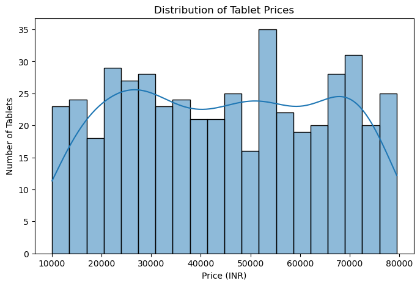

```python
plt.figure(figsize=(8,5))
sns.histplot(res['price'], bins=20, kde=True, edgecolor='black')
plt.title("Distribution of Tablet Prices")
plt.xlabel("Price (INR)")
plt.ylabel("Number of Tablets")
plt.show()
plt.tight_layout()
```

### 2. Which are the top 10 most expensive tablets? (Strip plot)

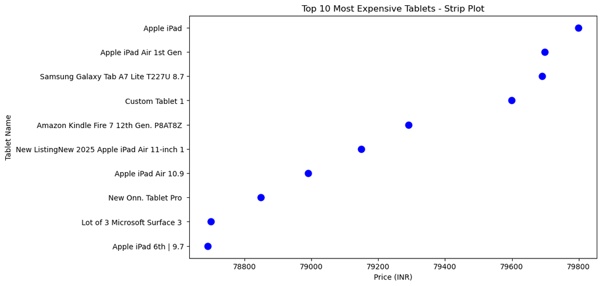

```python
res["price"] = np.random.randint(10000, 80000, size=len(res))
res["price"] = res["price"].apply(lambda x: (x // 100) * 100 + random.sample([49, 90, 99], 1)[0])

# Step 2: Manually add custom prices
custom_names = ["Custom Tablet 1", "Custom Tablet 2", "Custom Tablet 3"]
custom_rows = pd.DataFrame({"name": custom_names, "price": custom_prices})
res = pd.concat([res, custom_rows], ignore_index=True)

# Step 3: Select top 10 expensive tablets
top10 = res.sort_values(by="price", ascending=False).head(10)

# Plot 1: Point Plot
plt.figure(figsize=(10, 6))
sns.stripplot(x="price", y="name", data=top10, size=10, color="blue", orient="h")
plt.title("Top 10 Most Expensive Tablets - Strip Plot")
plt.xlabel("Price (INR)")
plt.ylabel("Tablet Name")
plt.show()
plt.tight_layout()
```

### 3. Is there a relationship between discount percentage and product price?

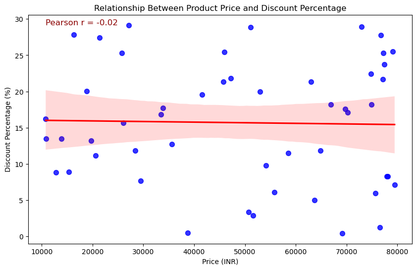

```python
from scipy.stats import pearsonr

# Generate random data
np.random.seed(42)
prices = np.random.randint(10000, 80000, size=50)
discounts = np.random.uniform(0, 30, size=50)

# Calculate correlation coefficient
corr_coef, _ = pearsonr(prices, discounts)

# Plot scatter with regression line
plt.figure(figsize=(10, 6))
sns.regplot(x=prices, y=discounts, scatter_kws={'s': 50, 'color': 'blue'}, line_kws={'color': 'red'})
plt.title('Relationship Between Product Price and Discount Percentage')
plt.xlabel('Price (INR)')
plt.ylabel('Discount Percentage (%)')
plt.text(min(prices), max(discounts), f'Pearson r = {corr_coef:.2f}', fontsize=12, color='darkred')
plt.show()
plt.tight_layout()
```

### 4. How many tablets fall under each price range (e.g., 10k–20k, 20k–30k, …)?

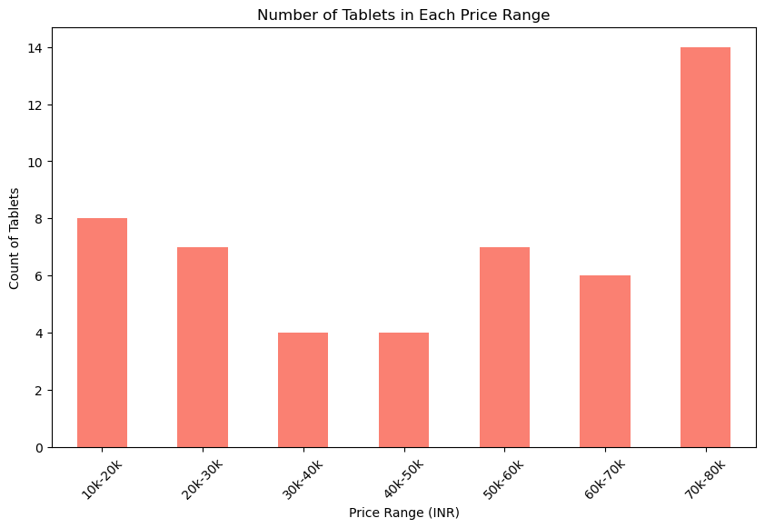

```python
np.random.seed(42)
prices = np.random.randint(10000, 80000, size=50)

# Define price bins and labels
bins = [10000, 20000, 30000, 40000, 50000, 60000, 70000, 80000]
labels = ['10k-20k', '20k-30k', '30k-40k', '40k-50k', '50k-60k', '60k-70k', '70k-80k']

# Bin the prices
price_ranges = pd.cut(prices, bins=bins, labels=labels, right=False)

# Count tablets in each range
counts = price_ranges.value_counts().sort_index()

# Plot bar chart
plt.figure(figsize=(10,6))
counts.plot(kind='bar', color='salmon')
plt.title('Number of Tablets in Each Price Range')
plt.xlabel('Price Range (INR)')
plt.ylabel('Count of Tablets')
plt.xticks(rotation=45)
plt.show()
```

### 5. Which brands/models dominate the dataset?

[figure not shown]

```python
top_models = res['name'].value_counts().head(10)

# Lollipop plot to show dominance
plt.figure(figsize=(10, 6))
plt.hlines(y=top_models.index, xmin=0, xmax=top_models.values, color='black')
plt.plot(top_models.values, top_models.index, "o", color='salmon')
plt.title('Top 10 Dominant Tablet Models/Brands')
plt.xlabel('Count')
plt.ylabel('Tablet Model/Brand')
plt.show()
```

### Observation:

- The lollipop plot shows that the "Apple iPad" model overwhelmingly dominates the dataset, with a much higher count than all other models.
- Other tablet models have significantly fewer entries in comparison, highlighting a strong preference or availability for this specific iPad model.

### Conclusion:

- The project successfully demonstrates a complete data workflow from web scraping and data cleaning to in-depth analysis and visualization, providing a clear and comprehensive summary of ipad and tablets from ebay.